# AI-Powered Engineering Drawing Change Detection System

Automated Comparison of Engineering Drawings using Computer Vision and OCR

*Author*

**Author: Ramu Gopal**

**Senior Mechanical Design Engineer | CAD Automation Specialist**

*Project*

**Project: AI-Assisted Engineering Drawing Change Detection System**

This notebook demonstrates a prototype system for automatically detecting differences between engineering drawing revisions using computer vision, OCR text extraction, and engineering token analysis.

*Developed By*

**Developed by Ramu Gopal**, **founder of The Tech Thinker**, a technology platform focused on:

- CAD automation
- engineering productivity tools
- AI applications in engineering workflows
- Digital Engineering

*Platform*

- Project published as part of the The Tech Thinker knowledge platform.

Website: [The Tech Thinker](https://thetechthinker.com)

*Keywords*

Engineering drawing comparison, CAD automation, drawing checker, computer vision for engineering, OCR drawing analysis.

**1. Introduction**

Engineering drawings are the primary communication medium in mechanical design and manufacturing. During product development, drawings are frequently revised to incorporate design improvements, manufacturing feedback, or engineering corrections.

However, identifying the exact changes between two drawing revisions can be difficult and time-consuming. Engineers often compare drawings manually, scanning multiple views, annotations, and notes to detect modifications.

This manual process introduces several challenges:

- High risk of overlooking small changes
- Time-consuming review process
- Inconsistent interpretation across engineers
- Difficulty documenting revision differences

To address these issues, this project proposes an AI-assisted drawing comparison system that automatically analyzes two engineering drawings and identifies potential differences using computer vision and OCR techniques.

**2. Problem Statement**

In many engineering organizations, revision checking is still performed manually by engineers or quality reviewers.

Typical workflow:

- Open the previous drawing revision.
- Open the new revision.
- Compare views, annotations, dimensions, and notes.
- Manually identify changes.

This process becomes inefficient when:

- Drawings contain multiple views
- Revisions are frequent
- Minor changes occur in annotations or notes
- Large drawing sets must be validated

Therefore, an automated method is required to:

- Detect visual differences between drawing revisions
- Identify annotation and dimension changes
- Extract and compare engineering tokens from OCR text
- Provide structured change summaries

**3. Objective of the Project**

The objective of this project is to develop a prototype automated drawing checker capable of comparing two engineering drawings and identifying potential changes.

The system aims to:

- Align two drawing revisions for accurate comparison
- Detect visual differences using pixel analysis
- Extract engineering text using OCR
- Identify token-level changes such as:
- labels
- dimensions
- angles
- chamfers
- Generate a structured engineering change report
- Evaluate detection performance using standard metrics

**4. Scope of the System**

The current prototype focuses on a limited set of drawing components.

The system analyzes the following regions:

- Section views
- Front views
- Side views
- Isometric views
- Notes block

Detected change types include:

- Label additions or removals
- Dimension additions or removals
- Possible dimension modifications
- Notes changes

The system produces a structured summary for each Region of Interest (ROI).

**5. Methodology Overview**

The proposed drawing comparison system follows a multi-stage processing pipeline.

Main stages include:

- Drawing Image Preprocessing
- Drawing Alignment
- Global Pixel Difference Detection
- Region of Interest (ROI) Extraction
- OCR Text Extraction
- Engineering Token Extraction
- Token Change Analysis
- Engineering Change Interpretation
- Evaluation using Ground Truth

This structured approach combines computer vision techniques with text-based analysis to improve detection reliability.

**6. System Architecture**

The system consists of the following functional modules:

- Image preprocessing module
- Drawing alignment module
- ROI detection module
- OCR text extraction module
- Engineering token extraction module
- Token comparison module
- Engineering change reporting module
- Evaluation module

These modules collectively form an automated pipeline for drawing revision comparison.

**7. Evaluation Approach**

To assess the effectiveness of the system, a ground truth dataset was manually defined for the test drawing pair.

- Evaluation metrics include:
- ROI change detection accuracy
- Change-type classification accuracy
- Engineering token extraction accuracy
- Precision, recall, and F1 score

The evaluation provides a quantitative measure of the system’s ability to detect engineering drawing changes.

**8. Expected Output**

The system generates a structured engineering change report for each drawing region.

Typical outputs include:

- Detected label additions or removals
- Possible dimension modifications
- Token-level annotation differences
- ROI change confidence levels

The system also produces evaluation tables and visualizations such as:

- confusion matrix
- detection metrics
- ROI outcome charts

**9. Applications**

This automated drawing checker concept can be applied in several engineering workflows:

- Design revision verification
- Manufacturing drawing validation
- Engineering change management
- Quality inspection of drawings
- Automated documentation review

With further development, such systems could integrate with CAD platforms or PLM systems to assist engineers during design review processes.

### Step 1 – Mount Google Drive

```python
from google.colab import drive
drive.mount("/content/drive")
```

### Step 2 – Create Project Folder Structure

```python
import os
from pathlib import Path

ROOT = Path("/content/drive/MyDrive/Drawing_Checker")

# Define folder structure
folders = [
    ROOT / "input/old",
    ROOT / "input/new",
    ROOT / "templates/masks",
    ROOT / "templates/capture",
    ROOT / "templates/bom",
    ROOT / "templates/notes",
    ROOT / "output/aligned",
    ROOT / "output/geometry_diff",
    ROOT / "output/annotated",
    ROOT / "output/final",
]

# Create all folders
for f in folders:
    f.mkdir(parents=True, exist_ok=True)

folders
```

```
[PosixPath('/content/drive/MyDrive/Drawing_Checker/input/old'),
 PosixPath('/content/drive/MyDrive/Drawing_Checker/input/new'),
 PosixPath('/content/drive/MyDrive/Drawing_Checker/templates/masks'),
 PosixPath('/content/drive/MyDrive/Drawing_Checker/templates/capture'),
 PosixPath('/content/drive/MyDrive/Drawing_Checker/templates/bom'),
 PosixPath('/content/drive/MyDrive/Drawing_Checker/templates/notes'),
 PosixPath('/content/drive/MyDrive/Drawing_Checker/output/aligned'),
 PosixPath('/content/drive/MyDrive/Drawing_Checker/output/geometry_diff'),
 PosixPath('/content/drive/MyDrive/Drawing_Checker/output/annotated'),
 PosixPath('/content/drive/MyDrive/Drawing_Checker/output/final')]
```

### Step 3 – Install Required Libraries

```python
# Install Required Libraries

!pip install opencv-python-headless=='4.8.0.74'
!pip install pdf2image
!pip install pytesseract
!pip install pillow
!pip install numpy
!pip install matplotlib
!pip install reportlab
!apt-get install poppler-utils -y

print("✔ All libraries installed successfully.")
```

```
Reading package lists... Done
Building dependency tree... Done
Reading state information... Done
poppler-utils is already the newest version (22.02.0-2ubuntu0.12).
0 upgraded, 0 newly installed, 0 to remove and 2 not upgraded.
✔ All libraries installed successfully.
```

### Step 4 – Update and Verify OpenCV Installation

```python
!pip uninstall -y opencv-python-headless
!pip install opencv-python-headless==4.12.0.88

import cv2
print("OpenCV version:", cv2.__version__)
```

```
Found existing installation: opencv-python-headless 4.8.0.74
Uninstalling opencv-python-headless-4.8.0.74:
  Successfully uninstalled opencv-python-headless-4.8.0.74
  Using cached opencv_python_headless-4.12.0.88-cp37-abi3-manylinux2014_x86_64.manylinux_2_17_x86_64.whl.metadata (19 kB)
Using cached opencv_python_headless-4.12.0.88-cp37-abi3-manylinux2014_x86_64.manylinux_2_17_x86_64.whl (54.0 MB)
OpenCV version: 4.12.0
```

### Step 5 – Define Old and New Drawing File Paths

```python
#Set Old/New TIFF Paths (Google Drive Version)

OLD_IMG = "/content/drive/MyDrive/Drawing_Checker/input/old/Old_Drawing.tiff"
NEW_IMG = "/content/drive/MyDrive/Drawing_Checker/input/new/New_Drawing.tiff"

print("OLD:", OLD_IMG)
print("NEW:", NEW_IMG)
```

```
OLD: /content/drive/MyDrive/Drawing_Checker/input/old/Old_Drawing.tiff
NEW: /content/drive/MyDrive/Drawing_Checker/input/new/New_Drawing.tiff
```

### Step 6 – Verify Drawing File Availability

```python
from pathlib import Path

old_path = Path(OLD_IMG)
new_path = Path(NEW_IMG)

print("Old exists:", old_path.exists(), "| Size (MB):", round(old_path.stat().st_size/1024/1024, 2) if old_path.exists() else "NA")
print("New exists:", new_path.exists(), "| Size (MB):", round(new_path.stat().st_size/1024/1024, 2) if new_path.exists() else "NA")

assert old_path.exists(), "❌ OLD TIFF not found. Check OLD_IMG path."
assert new_path.exists(), "❌ NEW TIFF not found. Check NEW_IMG path."

print("✅ Both TIFF files found.")
```

```
Old exists: True | Size (MB): 1.59
New exists: True | Size (MB): 1.69
✅ Both TIFF files found.
```

### Step 7 – Configure Stable Library Environment

```python
#Stable Library Setup

!pip -q install -U opencv-python-headless==4.12.0.88 pytesseract reportlab

import cv2
print("✅ OpenCV:", cv2.__version__)
```

```
✅ OpenCV: 4.12.0
```

### Step 8 – Initialize Drawing Page Containers

```python
from pathlib import Path

BASE = Path("/content/drive/MyDrive/Drawing_Checker")

PAGES_OLD_DIR = BASE / "output" / "pages_old"
PAGES_NEW_DIR = BASE / "output" / "pages_new"
PAGES_OLD_DIR.mkdir(parents=True, exist_ok=True)
PAGES_NEW_DIR.mkdir(parents=True, exist_ok=True)


old_pages = [Path(OLD_IMG)]
new_pages = [Path(NEW_IMG)]

print("✅ OLD pages:", len(old_pages), "| file:", old_pages[0])
print("✅ NEW pages:", len(new_pages), "| file:", new_pages[0])
```

```
✅ OLD pages: 1 | file: /content/drive/MyDrive/Drawing_Checker/input/old/Old_Drawing.tiff
✅ NEW pages: 1 | file: /content/drive/MyDrive/Drawing_Checker/input/new/New_Drawing.tiff
```

### Step 9 – Compare Drawing Page Counts

```python
old_n, new_n = len(old_pages), len(new_pages)
min_pages = min(old_n, new_n)


print("OLD:", old_n, "pages")
print("NEW:", new_n, "pages")
print("We will compare:", min_pages, "page(s)")

if old_n != new_n:
    print("⚠️ Page count mismatch — extra pages will be flagged later.")
else:
    print("✅ Page counts match.")
```

```
OLD: 1 pages
NEW: 1 pages
We will compare: 1 page(s)
✅ Page counts match.
```

### Step 10 – Preview Drawing Pages

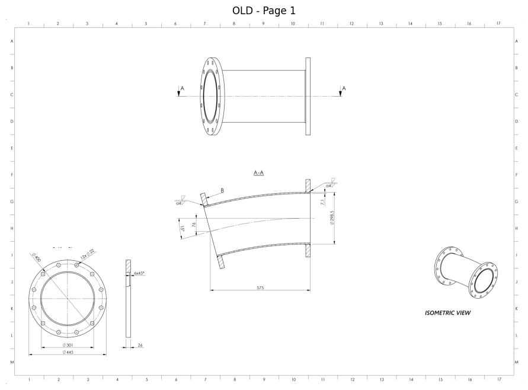

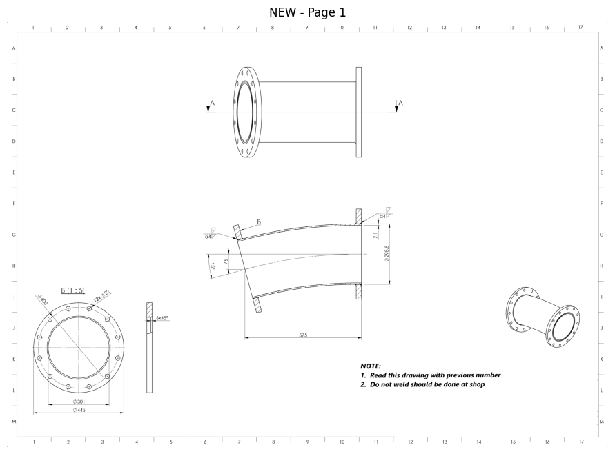

```python
from PIL import Image
import matplotlib.pyplot as plt

def show(img_path, title):
    img = Image.open(img_path)
    plt.figure(figsize=(12,8))
    plt.imshow(img)
    plt.axis("off")
    plt.title(title)
    plt.show()

if min_pages > 0:
    show(old_pages[0], "OLD - Page 1")
    show(new_pages[0], "NEW - Page 1")
```

### Step 11 – Define Image Alignment Functio

```python
import cv2
import numpy as np
from pathlib import Path

ALIGNED_DIR = BASE / "output" / "aligned"
ALIGNED_DIR.mkdir(parents=True, exist_ok=True)

def align_images(old_img_path, new_img_path, out_path):
    old_img = cv2.imread(str(old_img_path), cv2.IMREAD_GRAYSCALE)
    new_img = cv2.imread(str(new_img_path), cv2.IMREAD_GRAYSCALE)

    # ORB detector
    orb = cv2.ORB_create(5000)
    kp1, des1 = orb.detectAndCompute(old_img, None)
    kp2, des2 = orb.detectAndCompute(new_img, None)

    # Matcher
    bf = cv2.BFMatcher(cv2.NORM_HAMMING, crossCheck=True)
    matches = bf.match(des1, des2)
    matches = sorted(matches, key=lambda x: x.distance)

    good_matches = matches[:150]

    pts1 = np.float32([kp1[m.queryIdx].pt for m in good_matches]).reshape(-1,1,2)
    pts2 = np.float32([kp2[m.trainIdx].pt for m in good_matches]).reshape(-1,1,2)

    # Homography
    H, _ = cv2.findHomography(pts2, pts1, cv2.RANSAC, 5.0)

    height, width = old_img.shape
    aligned = cv2.warpPerspective(cv2.imread(str(new_img_path)), H, (width, height))

    cv2.imwrite(str(out_path), aligned)
    return out_path
```

### Step 12 – Execute Drawing Alignment

```python
aligned_p1 = ALIGNED_DIR / "aligned_p001.png"

out = align_images(old_pages[0], new_pages[0], aligned_p1)
print("Aligned output:", out)
```

```
Aligned output: /content/drive/MyDrive/Drawing_Checker/output/aligned/aligned_p001.png
```

### Step 13 – Preview Aligned Drawing

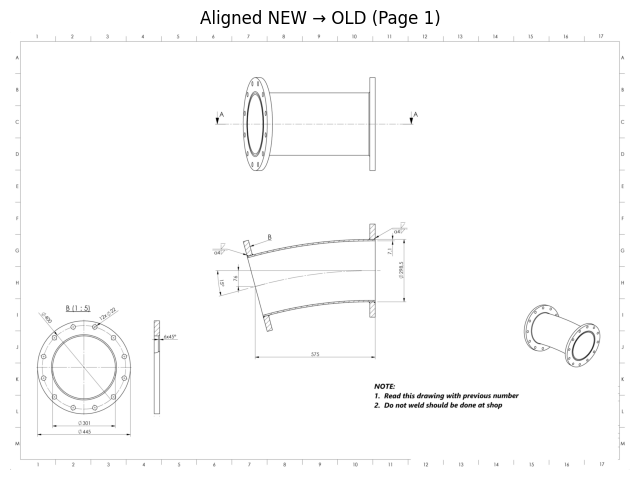

```python
from PIL import Image
import matplotlib.pyplot as plt

img = Image.open(aligned_p1)
plt.figure(figsize=(8,6))
plt.imshow(img)
plt.axis("off")
plt.title("Aligned NEW → OLD (Page 1)")
plt.show()
```

### Step 14 – Create Output Directories for Diff and Reports

```python
GEOM_DIR = BASE / "output" / "geometry_diff"
ANN_DIR  = BASE / "output" / "annotated"
FINAL_DIR = BASE / "output" / "final"

GEOM_DIR.mkdir(parents=True, exist_ok=True)
ANN_DIR.mkdir(parents=True, exist_ok=True)
FINAL_DIR.mkdir(parents=True, exist_ok=True)

print("Folders ready:")
print(GEOM_DIR)
print(ANN_DIR)
print(FINAL_DIR)
```

```
Folders ready:
/content/drive/MyDrive/Drawing_Checker/output/geometry_diff
/content/drive/MyDrive/Drawing_Checker/output/annotated
/content/drive/MyDrive/Drawing_Checker/output/final
```

### Step 15 – Define Geometry Difference Detection Function

```python
import cv2
import numpy as np

def generate_diff(old_img, aligned_img, diff_mask_path, annotated_path):
    # Read images
    img_old = cv2.imread(str(old_img), cv2.IMREAD_GRAYSCALE)
    img_new = cv2.imread(str(aligned_img), cv2.IMREAD_GRAYSCALE)

    # Smooth (reduces noise)
    old_blur = cv2.GaussianBlur(img_old, (5,5), 0)
    new_blur = cv2.GaussianBlur(img_new, (5,5), 0)

    # Absolute diff → main engine
    diff = cv2.absdiff(old_blur, new_blur)

    # Threshold to binary
    _, thresh = cv2.threshold(diff, 30, 255, cv2.THRESH_BINARY)

    # Morph (clean)
    kernel = np.ones((5,5), np.uint8)
    clean = cv2.morphologyEx(thresh, cv2.MORPH_OPEN, kernel)
    clean = cv2.dilate(clean, kernel, iterations=1)

    # Save diff mask
    cv2.imwrite(str(diff_mask_path), clean)

    # Create red overlay annotation
    color_new = cv2.cvtColor(img_new, cv2.COLOR_GRAY2BGR)
    overlay = color_new.copy()
    overlay[clean > 0] = (0,0,255)   # RED highlights

    alpha = 0.65
    annotated = cv2.addWeighted(color_new, alpha, overlay, 1 - alpha, 0)

    cv2.imwrite(str(annotated_path), annotated)

    return diff_mask_path, annotated_path
```

### Step 16 – Generate Geometry Difference Mask and Annotation

```python
DIFF_P1 = GEOM_DIR / "p001_mask.png"
ANN_P1  = ANN_DIR  / "p001_annotated.png"

generate_diff(old_pages[0], aligned_p1, DIFF_P1, ANN_P1)

print("Diff Mask:", DIFF_P1)
print("Annotated:", ANN_P1)
```

```
Diff Mask: /content/drive/MyDrive/Drawing_Checker/output/geometry_diff/p001_mask.png
Annotated: /content/drive/MyDrive/Drawing_Checker/output/annotated/p001_annotated.png
```

### Step 17 – Preview Geometry Difference Results

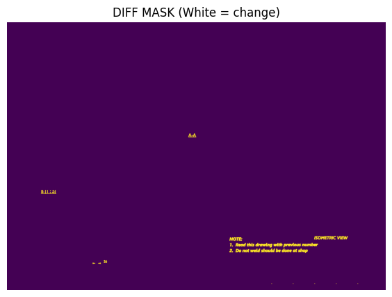

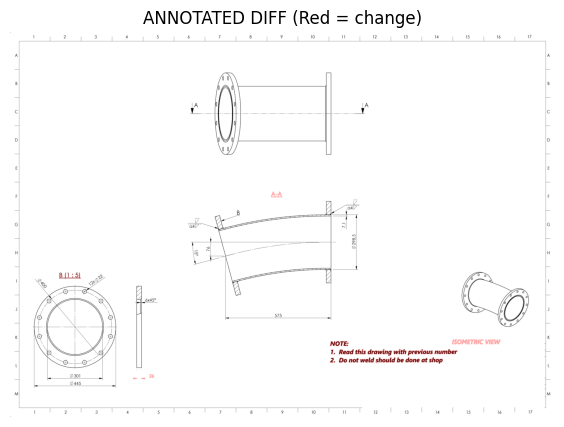

```python
from PIL import Image
import matplotlib.pyplot as plt

def preview(img_path, title):
    img = Image.open(img_path)
    plt.figure(figsize=(8,5))
    plt.imshow(img)
    plt.axis("off")
    plt.title(title)
    plt.show()

preview(DIFF_P1, "DIFF MASK (White = change)")
preview(ANN_P1, "ANNOTATED DIFF (Red = change)")
```

### Step 18 – Define ROI Templates for Drawing Regions

```python
ROI_TEMPLATE = {
    "section_view":      {"x1": 0.30, "y1": 0.34, "x2": 0.66, "y2": 0.76},
    "front_face_view":   {"x1": 0.03, "y1": 0.58, "x2": 0.24, "y2": 0.95},
    "front_side_view":   {"x1": 0.23, "y1": 0.60, "x2": 0.32, "y2": 0.93},
    "iso_view":          {"x1": 0.74, "y1": 0.56, "x2": 0.95, "y2": 0.80},
    "notes_block":       {"x1": 0.58, "y1": 0.82, "x2": 0.90, "y2": 0.94}
}
```

### Step 19 – Visualize ROI Template on Drawing

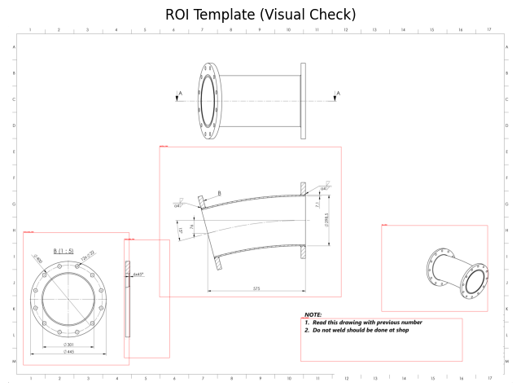

```python
import cv2
import matplotlib.pyplot as plt
from PIL import Image

img = cv2.imread(str(aligned_p1))
h, w = img.shape[:2]

for name, box in ROI_TEMPLATE.items():
    x1 = int(box["x1"] * w)
    y1 = int(box["y1"] * h)
    x2 = int(box["x2"] * w)
    y2 = int(box["y2"] * h)
    cv2.rectangle(img, (x1,y1), (x2,y2), (0,0,255), 2)
    cv2.putText(img, name, (x1, y1-5), cv2.FONT_HERSHEY_SIMPLEX, 0.6, (0,0,255), 2)

plt.figure(figsize=(8,6))
plt.imshow(cv2.cvtColor(img, cv2.COLOR_BGR2RGB))
plt.axis("off")
plt.title("ROI Template (Visual Check)")
plt.show()
```

### Step 20 – Define ROI-Based Difference Function

```python
def roi_diff(aligned_img_path, old_img_path, roi_box, out_path):
    # load images
    old = cv2.imread(str(old_img_path), cv2.IMREAD_GRAYSCALE)
    new = cv2.imread(str(aligned_img_path), cv2.IMREAD_GRAYSCALE)

    h, w = old.shape[:2]

    # extract ROI region
    x1 = int(roi_box["x1"] * w)
    y1 = int(roi_box["y1"] * h)
    x2 = int(roi_box["x2"] * w)
    y2 = int(roi_box["y2"] * h)

    old_roi = old[y1:y2, x1:x2]
    new_roi = new[y1:y2, x1:x2]

    # absolute diff
    diff = cv2.absdiff(old_roi, new_roi)
    _, mask = cv2.threshold(diff, 30, 255, cv2.THRESH_BINARY)

    # cleanup noise
    kernel = np.ones((3,3),np.uint8)
    mask = cv2.morphologyEx(mask, cv2.MORPH_OPEN, kernel)
    mask = cv2.dilate(mask, kernel, iterations=1)

    cv2.imwrite(str(out_path), mask)

    # --- NEW PART ---
    changed_pixels = np.sum(mask > 0)
    total_pixels = mask.size
    change_percent = (changed_pixels / total_pixels) * 100

    return out_path, change_percent
```

### Step 21 – Execute ROI-Based Difference Analysis

```python
roi = ROI_TEMPLATE

roi_output_dir = BASE / "output" / "roi_diff"
roi_output_dir.mkdir(exist_ok=True)

roi_results = {}
roi_change_stats = {}

for name, box in roi.items():
    out_file = roi_output_dir / f"p001_{name}.png"
    saved_file, change_percent = roi_diff(aligned_p1, old_pages[0], box, out_file)
    roi_results[name] = saved_file
    roi_change_stats[name] = round(change_percent, 2)

print("ROI diff files:")
print(roi_results)

print("\nROI change percentages:")
for k, v in roi_change_stats.items():
    print(f"{k:15s} : {v:.2f}%")
```

```
ROI diff files:
{'section_view': PosixPath('/content/drive/MyDrive/Drawing_Checker/output/roi_diff/p001_section_view.png'), 'front_face_view': PosixPath('/content/drive/MyDrive/Drawing_Checker/output/roi_diff/p001_front_face_view.png'), 'front_side_view': PosixPath('/content/drive/MyDrive/Drawing_Checker/output/roi…

ROI change percentages:
section_view    : 0.06%
front_face_view : 0.21%
front_side_view : 0.17%
iso_view        : 0.11%
notes_block     : 6.75%
```

### Step 22 – Visualize ROI Difference Results

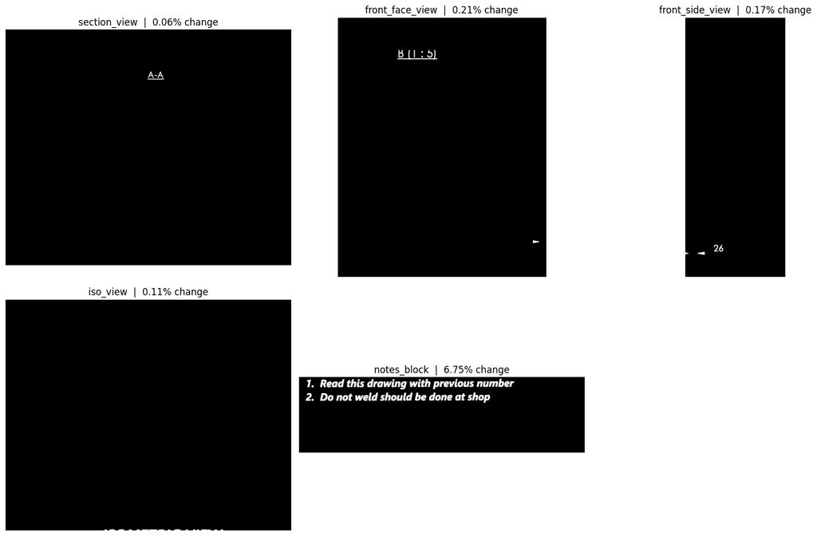

```python
import matplotlib.pyplot as plt
from PIL import Image
import math

files = list(roi_results.items())
n = len(files)

cols = 3
rows = math.ceil(n / cols)

plt.figure(figsize=(16, 5 * rows))

for i, (name, file) in enumerate(files, start=1):
    plt.subplot(rows, cols, i)
    img = Image.open(file)
    plt.imshow(img, cmap='gray')

    pct = roi_change_stats.get(name, 0)
    plt.title(f"{name}  |  {pct:.2f}% change")

    plt.axis("off")

plt.tight_layout()
plt.show()
```

### Step 23 – Install and Verify Tesseract OCR

```python
!apt-get -y install tesseract-ocr
!tesseract --version
```

```
Reading package lists... Done
Building dependency tree... Done
Reading state information... Done
tesseract-ocr is already the newest version (4.1.1-2.1build1).
0 upgraded, 0 newly installed, 0 to remove and 2 not upgraded.
tesseract 4.1.1
 leptonica-1.82.0
  libgif 5.1.9 : libjpeg 8d (libjpeg-turbo 2.1.1) : libpng 1.6.37 : libtiff 4.3.0 : zlib 1.2.11 : libwebp 1.2.2 : libopenjp2 2.4.0
 Found AVX2
 Found AVX
 Found FMA
 Found SSE
 Found libarchive 3.6.0 zlib/1.2.11 liblzma/5.2.5 bz2lib/1.0.8 liblz4/1.9.3 libzstd/1.4.8
```

### Step 24 – Define OCR Extraction Function for ROI Text

```python
import pytesseract
import cv2
import numpy as np

def ocr_roi(image_path):

    img = cv2.imread(str(image_path), cv2.IMREAD_GRAYSCALE)

    # enlarge (important for CAD fonts)
    img = cv2.resize(img, None, fx=2.0, fy=2.0, interpolation=cv2.INTER_CUBIC)

    # light denoise (keep thin lines)
    img = cv2.bilateralFilter(img, 9, 75, 75)

    # adaptive threshold works better for drawings
    img = cv2.adaptiveThreshold(
        img,
        255,
        cv2.ADAPTIVE_THRESH_GAUSSIAN_C,
        cv2.THRESH_BINARY,
        31,
        5
    )

    config = "--oem 3 --psm 6"
    text = pytesseract.image_to_string(img, config=config)

    return text.strip()
```

### Step 25 – Define ROI Cropping Function

```python
import cv2
import numpy as np
from pathlib import Path

def crop_roi(img_path, roi_box):
    img = cv2.imread(str(img_path), cv2.IMREAD_GRAYSCALE)
    h, w = img.shape[:2]

    x1 = int(roi_box["x1"] * w)
    y1 = int(roi_box["y1"] * h)
    x2 = int(roi_box["x2"] * w)
    y2 = int(roi_box["y2"] * h)

    roi = img[y1:y2, x1:x2]
    return roi
```

### Step 26 – Define Enhanced OCR Function for CAD Text

```python
import pytesseract

def ocr_image(gray_roi):
    # enlarge
    roi = cv2.resize(gray_roi, None, fx=2.0, fy=2.0, interpolation=cv2.INTER_CUBIC)

    # light denoise only
    roi = cv2.bilateralFilter(roi, 9, 75, 75)

    # adaptive threshold works better for drawings
    roi = cv2.adaptiveThreshold(roi, 255, cv2.ADAPTIVE_THRESH_GAUSSIAN_C,
                                cv2.THRESH_BINARY, 31, 5)

    config = "--oem 3 --psm 6 -c tessedit_char_whitelist=0123456789ABCDEFGHIJKLMNOPQRSTUVWXYZ.-Ø°"
    text = pytesseract.image_to_string(roi, config=config)
    return text.strip()
```

### Step 27 – Define OCR Function for Notes Block

```python
def ocr_notes(gray_roi):
    roi = cv2.resize(gray_roi, None, fx=3.0, fy=3.0, interpolation=cv2.INTER_CUBIC)
    roi = cv2.GaussianBlur(roi, (3, 3), 0)

    # Try simple binary threshold for faint old-note text
    _, roi_bin = cv2.threshold(roi, 180, 255, cv2.THRESH_BINARY)

    config = "--oem 3 --psm 6"
    text = pytesseract.image_to_string(roi_bin, config=config)
    return text.strip()
```

#### Step 28 – Preview Cropped ROI for OCR

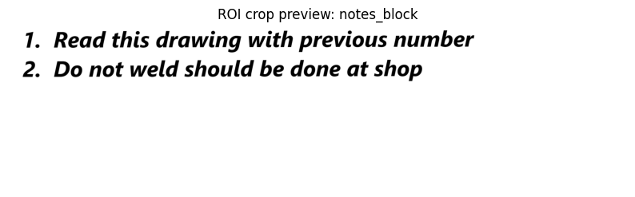

```python
from PIL import Image
import matplotlib.pyplot as plt

# try NOTES ROI first (usually easiest for OCR)
roi_name = "notes_block"
roi_img = crop_roi(aligned_p1, ROI_TEMPLATE[roi_name])

plt.figure(figsize=(10,3))
plt.imshow(roi_img, cmap="gray")
plt.axis("off")
plt.title(f"ROI crop preview: {roi_name}")
plt.show()
```

### Step 29 – Extract OCR Text from Drawing Notes Block

```python
ocr_output_old = {}
ocr_output_new = {}

OCR_ROIS = ["notes_block"]

for name in OCR_ROIS:
    box = ROI_TEMPLATE[name]
    old_roi = crop_roi(old_pages[0], box)
    new_roi = crop_roi(aligned_p1, box)

    if name == "notes_block":
        ocr_output_old[name] = ocr_notes(old_roi)
        ocr_output_new[name] = ocr_notes(new_roi)
    else:
        ocr_output_old[name] = ocr_image(old_roi)
        ocr_output_new[name] = ocr_image(new_roi)

for key in OCR_ROIS:
    print("\n======= ", key, " =======")
    print("OLD:\n", ocr_output_old[key])
    print("\nNEW:\n", ocr_output_new[key])
```

```
=======  notes_block  =======
OLD:


NEW:
 1. Read this drawing with previous number
2. Do not weld should be done at shop
```

### Step 30 – Normalize OCR Text and Compute Similarity

```python
import re
from difflib import SequenceMatcher

def normalize_text(s: str) -> str:
    if not s:
        return ""
    s = s.upper()
    s = s.replace("|", " ")
    s = re.sub(r"[^\w\s\.\-\[\]\/]", " ", s)   # keep basic tokens
    s = re.sub(r"\s+", " ", s).strip()
    return s

def similarity(a: str, b: str) -> float:
    a2, b2 = normalize_text(a), normalize_text(b)
    if not a2 and not b2:
        return 1.0
    return SequenceMatcher(None, a2, b2).ratio()
```

### Step 31 – Compute OCR Similarity Scores for ROIs

```python
roi_keys = OCR_ROIS

rows = []
for k in roi_keys:
    old_t = ocr_output_old.get(k, "")
    new_t = ocr_output_new.get(k, "")
    sim = similarity(old_t, new_t)
    rows.append((k, round(sim*100, 2)))

rows
```

```
[('notes_block', 0.0)]
```

### Step 32 – Evaluate OCR Similarity and Change Status

```python
for k, pct in rows:
    status = "PASS" if pct >= 95 else "CHANGE"
    print(f"{k:15s}  Similarity: {pct:6.2f}%   => {status}")
```

```
notes_block      Similarity:   0.00%   => CHANGE
```

### Step 33 – Generate OCR Change Summary

```python
summary = []

for key in ocr_output_old.keys():

    old_text = ocr_output_old.get(key, "")
    new_text = ocr_output_new.get(key, "")

    sim = similarity(old_text, new_text)

    if sim < 0.95:
        summary.append(f"{key} changed (similarity {round(sim*100,2)}%)")
    else:
        summary.append(f"{key} no major change")

print("\n✅ Auto Summary:")
for s in summary:
    print("-", s)
```

```
✅ Auto Summary:
- notes_block changed (similarity 0.0%)
```

### Step 34 – Classify Notes Changes Based on OCR Comparison

```python
roi_keys = OCR_ROIS

rows = []
for k in roi_keys:
    old_t = ocr_output_old.get(k, "").strip()
    new_t = ocr_output_new.get(k, "").strip()

    if not old_t and not new_t:
        status = "NO NOTES / NO CHANGE"
        sim_pct = 100.0
    elif not old_t and new_t:
        status = "NOTES ADDED"
        sim_pct = 0.0
    elif old_t and not new_t:
        status = "NOTES REMOVED"
        sim_pct = 0.0
    else:
        sim = similarity(old_t, new_t)
        sim_pct = round(sim * 100, 2)
        status = "NOTES SAME" if sim_pct >= 95 else "NOTES MODIFIED"

    rows.append((k, sim_pct, status))

rows
```

```
[('notes_block', 0.0, 'NOTES ADDED')]
```

### Step 35 – Generate Final Notes Comparison Report

```python
print("\nFINAL NOTES CHECK")
print("-" * 50)

for name, sim_pct, status in rows:
    pixel_pct = roi_change_stats.get(name, 0.0)

    print(f"ROI Name         : {name}")
    print(f"Pixel Change %   : {pixel_pct:.2f}%")
    print(f"Text Similarity  : {sim_pct:.2f}%")
    print(f"Notes Status     : {status}")
    print("-" * 50)
```

```
FINAL NOTES CHECK
--------------------------------------------------
ROI Name         : notes_block
Pixel Change %   : 6.75%
Text Similarity  : 0.00%
Notes Status     : NOTES ADDED
--------------------------------------------------
```

### Step 36 – Detect ROIs Exceeding Change Threshold

```python
CHANGE_THRESHOLD = 0.3   # percent

changed_rois = []

for name, pct in roi_change_stats.items():
    if pct >= CHANGE_THRESHOLD:
        changed_rois.append(name)

print("Changed ROIs detected:")
print(changed_rois)
```

```
Changed ROIs detected:
['notes_block']
```

### Step 37 – Identify Candidate View ROIs for Review

```python
VIEW_REVIEW_THRESHOLD = 0.05

candidate_view_rois = []

for name, pct in roi_change_stats.items():
    if name != "notes_block" and pct >= VIEW_REVIEW_THRESHOLD:
        candidate_view_rois.append(name)

print("Candidate view ROIs for deeper review:")
print(candidate_view_rois)
```

```
Candidate view ROIs for deeper review:
['section_view', 'front_face_view', 'front_side_view', 'iso_view']
```

### Step 38 – Crop Old and New Images for Candidate View ROIs

```python
# Crop old/new images for candidate view ROIs

view_roi_crops = {}

for name in candidate_view_rois:
    box = ROI_TEMPLATE[name]

    old_roi = crop_roi(old_pages[0], box)
    new_roi = crop_roi(aligned_p1, box)

    view_roi_crops[name] = {
        "old": old_roi,
        "new": new_roi
    }

print("Stored candidate ROI crops:")
print(list(view_roi_crops.keys()))
```

```
Stored candidate ROI crops:
['section_view', 'front_face_view', 'front_side_view', 'iso_view']
```

### Step 39 – Preview Old vs New Cropped View ROIs

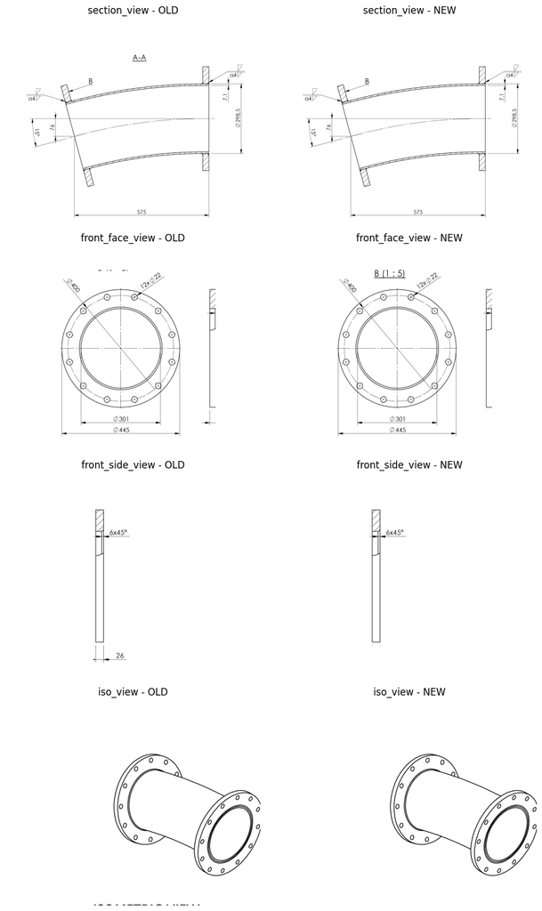

```python
#Preview old vs new cropped ROIs for candidate views

import matplotlib.pyplot as plt
import math

roi_names = list(view_roi_crops.keys())
n = len(roi_names)

rows = n
cols = 2

plt.figure(figsize=(10, 4 * rows))

for i, name in enumerate(roi_names, start=1):
    old_img = view_roi_crops[name]["old"]
    new_img = view_roi_crops[name]["new"]

    plt.subplot(rows, cols, 2*i - 1)
    plt.imshow(old_img, cmap="gray")
    plt.title(f"{name} - OLD")
    plt.axis("off")

    plt.subplot(rows, cols, 2*i)
    plt.imshow(new_img, cmap="gray")
    plt.title(f"{name} - NEW")
    plt.axis("off")

plt.tight_layout()
plt.show()
```

### Step 40 – Test OCR on Candidate View ROI

```python
#OCR test on candidate view ROI

test_roi = "front_side_view"

old_img = view_roi_crops[test_roi]["old"]
new_img = view_roi_crops[test_roi]["new"]

old_text = ocr_image(old_img)
new_text = ocr_image(new_img)

print("OLD OCR:")
print(old_text)

print("\nNEW OCR:")
print(new_text)
```

```
OLD OCR:
6X45°
26

NEW OCR:
6X45°
```

### Step 41 – Define Robust OCR Function for View ROI Tokens

```python
#Robust OCR for view ROIs (dimensions / labels / angles / diameter)

import cv2
import pytesseract
import re

def ocr_view_tokens(gray_roi):
    results = []

    scales = [2.0, 3.0, 4.0]
    psm_modes = [6, 11, 12]

    for sc in scales:
        roi = cv2.resize(gray_roi, None, fx=sc, fy=sc, interpolation=cv2.INTER_CUBIC)

        variants = []

        # Variant 1: simple binary
        _, th1 = cv2.threshold(roi, 180, 255, cv2.THRESH_BINARY)
        variants.append(th1)

        # Variant 2: adaptive threshold
        th2 = cv2.adaptiveThreshold(
            roi, 255,
            cv2.ADAPTIVE_THRESH_GAUSSIAN_C,
            cv2.THRESH_BINARY, 31, 5
        )
        variants.append(th2)

        # Variant 3: denoise + adaptive
        den = cv2.bilateralFilter(roi, 9, 75, 75)
        th3 = cv2.adaptiveThreshold(
            den, 255,
            cv2.ADAPTIVE_THRESH_GAUSSIAN_C,
            cv2.THRESH_BINARY, 31, 5
        )
        variants.append(th3)

        for img in variants:
            for psm in psm_modes:
                config = f"--oem 3 --psm {psm} -c tessedit_char_whitelist=0123456789ABCDEFGHIJKLMNOPQRSTUVWXYZabcdefghijklmnopqrstuvwxyz.-ØR°xX():[]/"
                txt = pytesseract.image_to_string(img, config=config).strip()
                if txt:
                    results.append(txt)

    return results
```

### Step 42 – Extract Engineering Tokens from OCR Text

```python
# Purpose:
#   Extract engineering tokens from OCR text and clean noisy dimension values.
# Inputs:
#   texts -> list of OCR text strings
# Outputs:
#   token dictionary with labels, diameter, radius, angle, linear, chamfer

import re

def normalize_eng_text(s: str) -> str:
    if not s:
        return ""
    s = s.replace("∅", "Ø").replace("φ", "Ø").replace("0/", "Ø").replace("O/", "Ø")
    s = s.replace("deg", "°").replace("DEG", "°")
    s = re.sub(r"\s+", " ", s).strip()
    return s


def extract_engineering_tokens(texts):
    if texts is None:
        texts = []

    joined = " | ".join([normalize_eng_text(t) for t in texts if t])

    tokens = {
        "labels": sorted(set(re.findall(r"\b[A-Z]-[A-Z]\b|\b[A-Z]\s*\(\s*\d+\s*:\s*\d+\s*\)", joined))),
        "diameter": sorted(set(re.findall(r"Ø\s*\d+(?:\.\d+)?", joined))),
        "radius": sorted(set(re.findall(r"R\s*\d+(?:\.\d+)?", joined))),
        "angle": sorted(set(re.findall(r"\d+(?:\.\d+)?\s*°", joined))),
        "linear": sorted(set(re.findall(r"(?<![A-ZØR])\b\d+(?:\.\d+)?\b", joined))),
        "chamfer": sorted(set(re.findall(r"\d+\s*[xX]\s*\d+(?:\.\d+)?\s*°", joined))),
    }

    # clean spaces inside tokens
    for k in tokens:
        tokens[k] = [re.sub(r"\s+", "", x) for x in tokens[k]]

    return tokens


def filter_dimension_noise(tokens):
    if tokens is None:
        return {
            "labels": [],
            "diameter": [],
            "radius": [],
            "angle": [],
            "linear": [],
            "chamfer": []
        }

    clean = {k: list(v) for k, v in tokens.items()}

    filtered_linear = []
    for x in clean.get("linear", []):
        try:
            val = float(x)
            if len(str(x)) >= 2 and val < 2000:
                filtered_linear.append(x)
        except:
            pass

    clean["linear"] = filtered_linear
    return clean
```

### STEP 43 — Dimension and Label Token Comparison for Changed ROI

```python
test_roi = "front_side_view"

old_img = view_roi_crops[test_roi]["old"]
new_img = view_roi_crops[test_roi]["new"]

old_texts = ocr_view_tokens(old_img)
new_texts = ocr_view_tokens(new_img)

old_tokens_raw = extract_engineering_tokens(old_texts)
new_tokens_raw = extract_engineering_tokens(new_texts)

old_tokens = filter_dimension_noise(old_tokens_raw)
new_tokens = filter_dimension_noise(new_tokens_raw)

print("ROI:", test_roi)

print("\nOLD OCR CANDIDATES:")
for t in old_texts[:10]:
    print("-", t)

print("\nNEW OCR CANDIDATES:")
for t in new_texts[:10]:
    print("-", t)

print("\nOLD TOKENS RAW:")
print(old_tokens_raw)

print("\nNEW TOKENS RAW:")
print(new_tokens_raw)

print("\nOLD TOKENS FILTERED:")
print(old_tokens)

print("\nNEW TOKENS FILTERED:")
print(new_tokens)
```

```
ROI: front_side_view

OLD OCR CANDIDATES:
- 6x45°
26
- 6x45°

[has
- 6x45°

[has
- 6x45°
26
- 6x45°

[Las
- 6x45°

[Las
- 6x45°
26
- 6x45°

[Los
- 6x45°

[Los
- 6x45°
26

NEW OCR CANDIDATES:
- 6x45°
- 6x45°
- 6x45°
- 6x45°
- 6x45°
- 6x45°
- 6x45°
- 6x45°
- 6x45°
- 6x45°

OLD TOKENS RAW:
{'labels': [], 'diameter': [], 'radius': [], 'angle': ['45°'], 'linear': ['26'], 'chamfer': ['6x45°']}

NEW TOKENS RAW:
{'labels': [], 'diameter': [], 'radius': [], 'angle': ['45°'], 'linear': [], 'chamfer': ['6x45°']}

OLD TOKENS FILTERED:
{'labels': [], 'diameter': [], 'radius': [], 'angle': ['45°'], 'linear': ['26'], 'chamfer': ['6x45°']}

NEW TOKENS FILTERED:
{'labels': [], 'diameter': [], 'radius': [], 'angle': ['45°'], 'linear': [], 'chamfer': ['6x45°']}
```

### STEP 44 — Engineering Token Change Detection (Added / Removed / Common)

```python
# Purpose:
#   Identify added / removed / unchanged engineering tokens for one ROI.
# Inputs:
#   old_tokens, new_tokens ->
# Outputs:
#   comparison dictionary with per-category changes

def compare_token_sets(old_tokens, new_tokens):
    categories = ["labels", "diameter", "radius", "angle", "linear", "chamfer"]

    report = {}

    for cat in categories:
        old_set = set(old_tokens.get(cat, []))
        new_set = set(new_tokens.get(cat, []))

        report[cat] = {
            "removed": sorted(list(old_set - new_set)),
            "added": sorted(list(new_set - old_set)),
            "common": sorted(list(old_set & new_set))
        }

    return report


token_report = compare_token_sets(old_tokens, new_tokens)

print("ROI:", test_roi)
print("\nTOKEN CHANGE REPORT:")
for cat, info in token_report.items():
    print(f"\n[{cat.upper()}]")
    print("  Removed:", info["removed"])
    print("  Added  :", info["added"])
    print("  Common :", info["common"])
```

[output not shown]

### STEP 45 — Engineering Token Change Confidence Assessment

```python
# Purpose:
#   Convert token difference report into human-readable engineering interpretation.
# Inputs:
#   token_report ->
#   old_texts, new_texts -> OCR candidate lists
# Outputs:
#   interpretation dictionary

def assess_token_change_confidence(token_report, old_texts, new_texts):
    total_removed = sum(len(v["removed"]) for v in token_report.values())
    total_added = sum(len(v["added"]) for v in token_report.values())

    old_count = len(old_texts) if old_texts else 0
    new_count = len(new_texts) if new_texts else 0

    noisy_old = any(("[" in str(x) or "]" in str(x)) for x in (old_texts or []))
    noisy_new = any(("[" in str(x) or "]" in str(x)) for x in (new_texts or []))

    if total_removed == 0 and total_added == 0:
        status = "NO TOKEN CHANGE"
        confidence = "HIGH"
        remark = "Same engineering tokens found in both old and new ROI."
    elif noisy_old or noisy_new:
        status = "POSSIBLE TOKEN CHANGE"
        confidence = "LOW"
        remark = "OCR noise detected. Token difference may be caused by OCR instability."
    elif old_count >= 5 and new_count >= 5:
        status = "LIKELY TOKEN CHANGE"
        confidence = "MEDIUM"
        remark = "Multiple OCR candidates found. Token difference may indicate a real annotation change."
    else:
        status = "POSSIBLE TOKEN CHANGE"
        confidence = "LOW"
        remark = "Limited OCR evidence. Manual review recommended."

    return {
        "status": status,
        "confidence": confidence,
        "remark": remark
    }


confidence_report = assess_token_change_confidence(token_report, old_texts, new_texts)

print("\nCONFIDENCE REPORT:")
for k, v in confidence_report.items():
    print(f"{k}: {v}")
```

```
CONFIDENCE REPORT:
status: POSSIBLE TOKEN CHANGE
confidence: LOW
remark: OCR noise detected. Token difference may be caused by OCR instability.
```

### STEP 46 — Build Structured ROI Engineering Change Summary

```python
# Purpose:
#   Convert token comparison + confidence result into a structured ROI report.
# Inputs:
#   roi_name, pixel_change_percent, token_report, confidence_report
# Outputs:
#   roi_summary dictionary

def build_roi_summary(roi_name, pixel_change_percent, token_report, confidence_report):
    total_removed = sum(len(v["removed"]) for v in token_report.values())
    total_added = sum(len(v["added"]) for v in token_report.values())

    changed_categories = []
    for cat, info in token_report.items():
        if info["removed"] or info["added"]:
            changed_categories.append(cat)

    remarks = []

    if "linear" in changed_categories:
        removed_linear = token_report["linear"]["removed"]
        added_linear = token_report["linear"]["added"]

        if removed_linear:
            remarks.append(f"Possible removed linear token(s): {removed_linear}")
        if added_linear:
            remarks.append(f"Possible added linear token(s): {added_linear}")

    if "labels" in changed_categories:
        if token_report["labels"]["removed"]:
            remarks.append(f"Possible removed label(s): {token_report['labels']['removed']}")
        if token_report["labels"]["added"]:
            remarks.append(f"Possible added label(s): {token_report['labels']['added']}")

    if not remarks:
        remarks.append("No strong token-level annotation difference detected.")

    roi_summary = {
        "roi_name": roi_name,
        "pixel_change_percent": pixel_change_percent,
        "changed_categories": changed_categories,
        "total_removed_tokens": total_removed,
        "total_added_tokens": total_added,
        "token_report": token_report,
        "status": confidence_report["status"],
        "confidence": confidence_report["confidence"],
        "remark": confidence_report["remark"],
        "engineering_note": " | ".join(remarks)
    }

    return roi_summary
```

### STEP 47 — Generate and Display Structured ROI Change Summary

```python
pixel_change_percent = roi_change_stats.get(test_roi, 0.0)

roi_summary = build_roi_summary(
    roi_name=test_roi,
    pixel_change_percent=pixel_change_percent,
    token_report=token_report,
    confidence_report=confidence_report
)

print("STRUCTURED ROI SUMMARY:\n")
for k, v in roi_summary.items():
    print(f"{k}: {v}")
```

```
STRUCTURED ROI SUMMARY:

roi_name: front_side_view
pixel_change_percent: 0.17
changed_categories: ['linear']
total_removed_tokens: 1
total_added_tokens: 0
token_report: {'labels': {'removed': [], 'added': [], 'common': []}, 'diameter': {'removed': [], 'added': [], 'common': []}, 'radius': {'removed': [], 'added': [], 'common': []}, 'angle': {'removed': [], 'added': [], 'common': ['45°']}, 'linear': {'removed': ['26'], 'added': [], 'common': []}, 'cham…
status: POSSIBLE TOKEN CHANGE
confidence: LOW
remark: OCR noise detected. Token difference may be caused by OCR instability.
engineering_note: Possible removed linear token(s): ['26']
```

### STEP 48 — Run Full ROI Engineering Change Analysis Pipeline

```python
# Purpose:
#   Run OCR token extraction, comparison, confidence assessment, and summary building
#   for each candidate ROI.
# Inputs:
#   candidate_view_rois, view_roi_crops, roi_change_stats
# Outputs:
#   final_roi_summaries dictionary

final_roi_summaries = {}

for roi_name in candidate_view_rois:
    old_img = view_roi_crops[roi_name]["old"]
    new_img = view_roi_crops[roi_name]["new"]

    old_texts = ocr_view_tokens(old_img)
    new_texts = ocr_view_tokens(new_img)

    old_tokens_raw = extract_engineering_tokens(old_texts)
    new_tokens_raw = extract_engineering_tokens(new_texts)

    old_tokens = filter_dimension_noise(old_tokens_raw)
    new_tokens = filter_dimension_noise(new_tokens_raw)

    token_report = compare_token_sets(old_tokens, new_tokens)
    confidence_report = assess_token_change_confidence(token_report, old_texts, new_texts)

    pixel_change_percent = roi_change_stats.get(roi_name, 0.0)

    roi_summary = build_roi_summary(
        roi_name=roi_name,
        pixel_change_percent=pixel_change_percent,
        token_report=token_report,
        confidence_report=confidence_report
    )

    roi_summary["old_texts_preview"] = old_texts[:5] if old_texts else []
    roi_summary["new_texts_preview"] = new_texts[:5] if new_texts else []
    roi_summary["old_tokens"] = old_tokens
    roi_summary["new_tokens"] = new_tokens

    final_roi_summaries[roi_name] = roi_summary

print("STEP 48 complete.")
print("ROIs processed:", list(final_roi_summaries.keys()))
```

[output not shown]

### STEP 49 — Display Consolidated ROI Engineering Change Summary

```python
# Purpose:
#   Show a readable summary of all ROI-level results.
# Inputs:
#   final_roi_summaries
# Outputs:
#   printed summary report

for roi_name, info in final_roi_summaries.items():
    print("\n" + "="*70)
    print("ROI:", roi_name)
    print("Pixel Change %:", info["pixel_change_percent"])
    print("Status:", info["status"])
    print("Confidence:", info["confidence"])
    print("Changed Categories:", info["changed_categories"])
    print("Engineering Note:", info["engineering_note"])
```

```
======================================================================
ROI: section_view
Pixel Change %: 0.06
Status: POSSIBLE TOKEN CHANGE
Confidence: LOW
Changed Categories: ['labels', 'linear']
Engineering Note: Possible added linear token(s): ['979'] | Possible removed label(s): ['A-A']

======================================================================
ROI: front_face_view
Pixel Change %: 0.21
Status: LIKELY TOKEN CHANGE
Confidence: MEDIUM
Changed Categories: ['labels']
Engineering Note: Possible added label(s): ['B(1:5)']

======================================================================
ROI: front_side_view
Pixel Change %: 0.17
Status: POSSIBLE TOKEN CHANGE
Confidence: LOW
Changed Categories: ['linear']
Engineering Note: Possible removed linear token(s): ['26']

======================================================================
ROI: iso_view
Pixel Change %: 0.11
Status: NO TOKEN CHANGE
Confidence: HIGH
Changed Categories: []
Engineering Note: No strong token-level annotation difference detected.
```

### STEP 50 — Categorize ROI Results into Engineering Review Buckets

```python
# Purpose:
#   Group ROI summaries into practical engineering review categories.
# Inputs:
#   final_roi_summaries
# Outputs:
#   roi_buckets dictionary

roi_buckets = {
    "likely_no_change": [],
    "possible_change_low_conf": [],
    "likely_change_medium_or_high": []
}

for roi_name, info in final_roi_summaries.items():
    status = info["status"]
    confidence = info["confidence"]

    if status == "NO TOKEN CHANGE":
        roi_buckets["likely_no_change"].append(roi_name)
    elif confidence == "LOW":
        roi_buckets["possible_change_low_conf"].append(roi_name)
    else:
        roi_buckets["likely_change_medium_or_high"].append(roi_name)

print("ROI BUCKETS:\n")
for k, v in roi_buckets.items():
    print(k, ":", v)
```

```
ROI BUCKETS:

likely_no_change : ['iso_view']
possible_change_low_conf : ['section_view', 'front_side_view']
likely_change_medium_or_high : ['front_face_view']
```

### STEP 51 — Detect Engineering Symbol Suspicion Flags from OCR Text

```python
# Purpose:
#   Inspect OCR text candidates and raise lightweight suspicion flags
#   for weld-related, GD&T-related, section-label, and view-label patterns.
# Inputs:
#   texts -> list of OCR text strings
# Outputs:
#   flags dictionary with boolean indicators

import re

def symbol_suspicion_flags(texts):
    if texts is None:
        texts = []

    safe_texts = [str(t) for t in texts if t is not None]
    joined = " | ".join(safe_texts).upper()

    flags = {
        "weld_suspected": any(
            x in joined for x in ["WELD", "FILLET", "V-GROOVE", "GROOVE"]
        ),
        "gdt_suspected": any(
            x in joined for x in ["DATUM", "TRUE POSITION", "FLATNESS", "PROFILE", "RUNOUT"]
        ),
        "section_label_suspected": bool(
            re.search(r"\b[A-Z]-[A-Z]\b", joined)
        ),
        "view_label_suspected": bool(
            re.search(r"\b[A-Z]\s*\(\s*\d+\s*:\s*\d+\s*\)", joined)
        ),
    }

    return flags
```

### STEP 52 — Validate and Display Engineering Symbol Suspicion Flags per ROI

```python
# Inputs:
#   candidate_view_rois, view_roi_crops, ocr_view_tokens
# Outputs:
#   printed flag summary and basic validation status

required_flag_keys = {
    "weld_suspected",
    "gdt_suspected",
    "section_label_suspected",
    "view_label_suspected",
}

for roi_name in candidate_view_rois:
    old_texts = ocr_view_tokens(view_roi_crops[roi_name]["old"])
    new_texts = ocr_view_tokens(view_roi_crops[roi_name]["new"])

    old_flags = symbol_suspicion_flags(old_texts)
    new_flags = symbol_suspicion_flags(new_texts)

    old_ok = isinstance(old_flags, dict) and required_flag_keys.issubset(old_flags.keys())
    new_ok = isinstance(new_flags, dict) and required_flag_keys.issubset(new_flags.keys())

    print("\n" + "-" * 60)
    print("ROI:", roi_name)
    print("OLD FLAGS:", old_flags, "| VALID:", old_ok)
    print("NEW FLAGS:", new_flags, "| VALID:", new_ok)
```

```
------------------------------------------------------------
ROI: section_view
OLD FLAGS: {'weld_suspected': False, 'gdt_suspected': False, 'section_label_suspected': True, 'view_label_suspected': False} | VALID: True
NEW FLAGS: {'weld_suspected': False, 'gdt_suspected': False, 'section_label_suspected': False, 'view_label_suspected': False} | VALID: True

------------------------------------------------------------
ROI: front_face_view
OLD FLAGS: {'weld_suspected': False, 'gdt_suspected': False, 'section_label_suspected': True, 'view_label_suspected': False} | VALID: True
NEW FLAGS: {'weld_suspected': False, 'gdt_suspected': False, 'section_label_suspected': True, 'view_label_suspected': True} | VALID: True

------------------------------------------------------------
ROI: front_side_view
OLD FLAGS: {'weld_suspected': False, 'gdt_suspected': False, 'section_label_suspected': False, 'view_label_suspected': False} | VALID: True
NEW FLAGS: {'weld_suspected': False, 'gdt_suspected': False, 'section_label_suspected': False, 'view_label_suspected': False} | VALID: True

------------------------------------------------------------
ROI: iso_view
OLD FLAGS: {'weld_suspected': False, 'gdt_suspected': False, 'section_label_suspected': False, 'view_label_suspected': False} | VALID: True
NEW FLAGS: {'weld_suspected': False, 'gdt_suspected': False, 'section_label_suspected': False, 'view_label_suspected': False} | VALID: True
```

### STEP 53 — Perform ROI-Level Engineering Token Difference Analysis

```python
# Purpose:
#   Compare engineering tokens between old and new images for one ROI.
# Inputs:
#   test_roi, view_roi_crops
# Outputs:
#   printed old/new token sets and token difference report

test_roi = "front_side_view"

if test_roi not in view_roi_crops:
    raise ValueError(f"ROI '{test_roi}' not found in view_roi_crops")

old_img = view_roi_crops[test_roi].get("old", None)
new_img = view_roi_crops[test_roi].get("new", None)

if old_img is None or new_img is None:
    raise ValueError(f"Missing old/new image data for ROI '{test_roi}'")

old_texts = ocr_view_tokens(old_img)
new_texts = ocr_view_tokens(new_img)

old_tokens_raw = extract_engineering_tokens(old_texts)
new_tokens_raw = extract_engineering_tokens(new_texts)

old_tokens = filter_dimension_noise(old_tokens_raw)
new_tokens = filter_dimension_noise(new_tokens_raw)

token_report = compare_token_sets(old_tokens, new_tokens)

print("ROI:", test_roi)

print("\nOLD TOKENS:")
print(old_tokens)

print("\nNEW TOKENS:")
print(new_tokens)

print("\nTOKEN CHANGE REPORT:")

has_change = False
for k, v in token_report.items():
    if v["added"] or v["removed"]:
        has_change = True
        print(f"\n{k.upper()}:")
        if v["added"]:
            print("  added  :", v["added"])
        if v["removed"]:
            print("  removed:", v["removed"])

if not has_change:
    print("No token-level differences detected.")
```

```
ROI: front_side_view

OLD TOKENS:
{'labels': [], 'diameter': [], 'radius': [], 'angle': ['45°'], 'linear': ['26'], 'chamfer': ['6x45°']}

NEW TOKENS:
{'labels': [], 'diameter': [], 'radius': [], 'angle': ['45°'], 'linear': [], 'chamfer': ['6x45°']}

TOKEN CHANGE REPORT:

LINEAR:
  removed: ['26']
```

### STEP 54 — Generate Comprehensive ROI Engineering Change Report

```python
# Purpose:
#   Build a structured per-ROI report using OCR text, engineering tokens,
#   token comparison, suspicion flags, and confidence assessment.
# Inputs:
#   candidate_view_rois, view_roi_crops, roi_change_stats
# Outputs:
#   final_view_report dictionary

final_view_report = {}

for roi_name in candidate_view_rois:
    roi_data = view_roi_crops.get(roi_name, {})
    old_img = roi_data.get("old", None)
    new_img = roi_data.get("new", None)

    if old_img is None or new_img is None:
        final_view_report[roi_name] = {
            "error": "Missing old/new ROI image",
            "pixel_change_percent": roi_change_stats.get(roi_name, 0.0),
        }
        continue

    old_texts = ocr_view_tokens(old_img)
    new_texts = ocr_view_tokens(new_img)

    old_tokens_raw = extract_engineering_tokens(old_texts)
    new_tokens_raw = extract_engineering_tokens(new_texts)

    old_tokens = filter_dimension_noise(old_tokens_raw)
    new_tokens = filter_dimension_noise(new_tokens_raw)

    token_report = compare_token_sets(old_tokens, new_tokens)

    old_flags = symbol_suspicion_flags(old_texts)
    new_flags = symbol_suspicion_flags(new_texts)

    confidence_report = assess_token_change_confidence(token_report, old_texts, new_texts)

    final_view_report[roi_name] = {
        "pixel_change_percent": roi_change_stats.get(roi_name, 0.0),
        "old_texts_preview": old_texts[:5] if old_texts else [],
        "new_texts_preview": new_texts[:5] if new_texts else [],
        "old_tokens": old_tokens,
        "new_tokens": new_tokens,
        "token_changes": token_report,
        "old_flags": old_flags,
        "new_flags": new_flags,
        "status": confidence_report["status"],
        "confidence": confidence_report["confidence"],
        "remark": confidence_report["remark"],
    }

print("STEP 54 complete.")
print(list(final_view_report.keys()))
```

```
STEP 54 complete.
['section_view', 'front_face_view', 'front_side_view', 'iso_view']
```

### STEP 55 — Validate Final ROI Report Structure

```python
# Purpose:
#   Validate report structure for all processed ROIs.
# Inputs:
#   final_view_report
# Outputs:
#   printed validation summary

required_keys = {
    "pixel_change_percent",
    "old_tokens",
    "new_tokens",
    "token_changes",
    "old_flags",
    "new_flags",
    "status",
    "confidence",
    "remark",
}

print("\nVALIDATION SUMMARY")
print("=" * 60)

for roi_name, info in final_view_report.items():
    if "error" in info:
        print(f"{roi_name}: ERROR -> {info['error']}")
        continue

    is_valid = required_keys.issubset(info.keys())
    print(f"{roi_name}: VALID = {is_valid}")
```

```
VALIDATION SUMMARY
============================================================
section_view: VALID = True
front_face_view: VALID = True
front_side_view: VALID = True
iso_view: VALID = True
```

### STEP 56 — Generate Human-Readable Engineering Change Summary

```python
# Purpose:
#   Produce a readable summary of engineering token differences
#   detected across candidate view ROIs.
# Inputs:
#   final_view_report
# Outputs:
#   printed engineering change summary

print("\nENGINEERING CHANGE SUMMARY")
print("=" * 70)

for roi_name, data in final_view_report.items():

    if "error" in data:
        print(f"\nROI: {roi_name}")
        print("  ERROR:", data["error"])
        continue

    pixel_pct = data.get("pixel_change_percent", 0.0)
    token_changes = data.get("token_changes", {})
    old_flags = data.get("old_flags", {})
    new_flags = data.get("new_flags", {})

    status = data.get("status", "UNKNOWN")
    confidence = data.get("confidence", "UNKNOWN")

    print(f"\nROI: {roi_name}")
    print(f"Pixel Change % : {pixel_pct:.2f}%")
    print(f"Status         : {status}")
    print(f"Confidence     : {confidence}")

    found_any = False

    for token_type, change in token_changes.items():

        added = change.get("added", [])
        removed = change.get("removed", [])

        if added or removed:
            found_any = True
            print(f"  {token_type.upper()}:")

            if added:
                print(f"    added   : {added}")

            if removed:
                print(f"    removed : {removed}")

    if old_flags.get("section_label_suspected") and not new_flags.get("section_label_suspected"):
        found_any = True
        print("  SECTION LABEL CHANGE:")
        print("    removed : section label suspected")

    if (not old_flags.get("view_label_suspected")) and new_flags.get("view_label_suspected"):
        found_any = True
        print("  VIEW LABEL CHANGE:")
        print("    added   : view label suspected")

    if not found_any:
        print("  No clear engineering token change detected")
```

```
ENGINEERING CHANGE SUMMARY
======================================================================

ROI: section_view
Pixel Change % : 0.06%
Status         : POSSIBLE TOKEN CHANGE
Confidence     : LOW
  LABELS:
    removed : ['A-A']
  LINEAR:
    added   : ['979']
  SECTION LABEL CHANGE:
    removed : section label suspected

ROI: front_face_view
Pixel Change % : 0.21%
Status         : LIKELY TOKEN CHANGE
Confidence     : MEDIUM
  LABELS:
    added   : ['B(1:5)']
  VIEW LABEL CHANGE:
    added   : view label suspected

ROI: front_side_view
Pixel Change % : 0.17%
Status         : POSSIBLE TOKEN CHANGE
Confidence     : LOW
  LINEAR:
    removed : ['26']

ROI: iso_view
Pixel Change % : 0.11%
Status         : NO TOKEN CHANGE
Confidence     : HIGH
  No clear engineering token change detected
```

### STEP 57 — Clean OCR Linear Dimension Tokens (Noise Filtering)

```python
# Purpose:
#   Remove unrealistic or noisy numeric tokens detected by OCR.
# Inputs:
#   tokens -> list of numeric dimension strings
# Outputs:
#   cleaned list of linear tokens

def clean_linear_tokens(tokens):

    if tokens is None:
        return []

    clean = []

    for t in tokens:
        try:
            v = float(t)

            # ignore very small OCR noise
            if v < 5:
                continue

            # ignore unrealistic large dimensions
            if v > 2000:
                continue

            clean.append(t)

        except:
            # ignore values that cannot be parsed
            continue

    return clean
```

### STEP 58 — Test Linear Token Cleaning Function

```python
test_tokens = ["1", "3", "5", "26", "2500", "12.5", "abc"]

print("INPUT :", test_tokens)
print("OUTPUT:", clean_linear_tokens(test_tokens))
```

```
INPUT : ['1', '3', '5', '26', '2500', '12.5', 'abc']
OUTPUT: ['5', '26', '12.5']
```

### STEP 59 — Detect Likely Dimension Modifications from Token Changes

```python
# Purpose:
#   Detect likely dimension modifications by pairing removed and added
#   linear tokens that are numerically close.
# Inputs:
#   token_changes -> token comparison report
# Outputs:
#   list of likely dimension modification strings

def detect_dimension_modifications(token_changes, tolerance=10.0):

    modifications = []

    if token_changes is None:
        return modifications

    added = token_changes.get("linear", {}).get("added", [])
    removed = token_changes.get("linear", {}).get("removed", [])

    added = clean_linear_tokens(added)
    removed = clean_linear_tokens(removed)

    used_added = set()

    for r in removed:
        try:
            r_val = float(r)
        except:
            continue

        best_match = None
        best_diff = None

        for a in added:
            if a in used_added:
                continue

            try:
                a_val = float(a)
            except:
                continue

            diff = abs(r_val - a_val)

            if diff <= tolerance:
                if best_diff is None or diff < best_diff:
                    best_diff = diff
                    best_match = a

        if best_match is not None:
            modifications.append(f"{r} → {best_match}")
            used_added.add(best_match)

    return modifications
```

### STEP 60 — Test Dimension Modification Detection

```python
sample_token_changes = {
    "linear": {
        "removed": ["25", "100", "12.5"],
        "added": ["26", "108", "13.0"],
        "common": []
    }
}

mods = detect_dimension_modifications(sample_token_changes, tolerance=10.0)

print("Detected modifications:")
print(mods)
```

```
Detected modifications:
['25 → 26', '100 → 108', '12.5 → 13.0']
```

### STEP 61 — Generate Engineering-Friendly Change Summary with Dimension Modification Detection

```python
# Purpose:
#   Print a more engineering-friendly summary including likely dimension
#   modifications, token additions/removals, and suspicion flag changes.
# Inputs:
#   final_view_report
# Outputs:
#   printed engineering change summary

print("\nENGINEERING CHANGE SUMMARY")
print("=" * 70)

for roi_name, data in final_view_report.items():

    if "error" in data:
        print(f"\nROI: {roi_name}")
        print("  ERROR:", data["error"])
        continue

    pixel_pct = data.get("pixel_change_percent", 0.0)
    token_changes = data.get("token_changes", {})
    old_flags = data.get("old_flags", {})
    new_flags = data.get("new_flags", {})
    status = data.get("status", "UNKNOWN")
    confidence = data.get("confidence", "UNKNOWN")

    print(f"\nROI: {roi_name}")
    print(f"Pixel Change % : {pixel_pct:.2f}%")
    print(f"Status         : {status}")
    print(f"Confidence     : {confidence}")

    found_any = False

    # detect likely dimension modifications
    mods = detect_dimension_modifications(token_changes)

    mod_removed = set()
    mod_added = set()

    if mods:
        found_any = True
        print("  DIMENSION MODIFIED:")
        for m in mods:
            print(f"    {m}")
            if "→" in m:
                left, right = m.split("→")
                mod_removed.add(left.strip())
                mod_added.add(right.strip())

    for token_type, change in token_changes.items():

        added = change.get("added", [])
        removed = change.get("removed", [])

        if token_type == "linear":
            added = clean_linear_tokens(added)
            removed = clean_linear_tokens(removed)

            # suppress values already reported as modifications
            added = [x for x in added if x not in mod_added]
            removed = [x for x in removed if x not in mod_removed]

        if added or removed:
            found_any = True
            print(f"  {token_type.upper()}:")

            if added:
                print(f"    added   : {added}")

            if removed:
                print(f"    removed : {removed}")

    if old_flags.get("section_label_suspected") and not new_flags.get("section_label_suspected"):
        found_any = True
        print("  SECTION LABEL CHANGE:")
        print("    removed : section label suspected")

    if (not old_flags.get("view_label_suspected")) and new_flags.get("view_label_suspected"):
        found_any = True
        print("  VIEW LABEL CHANGE:")
        print("    added   : view label suspected")

    if not found_any:
        print("  No clear engineering token change detected")
```

```
ENGINEERING CHANGE SUMMARY
======================================================================

ROI: section_view
Pixel Change % : 0.06%
Status         : POSSIBLE TOKEN CHANGE
Confidence     : LOW
  LABELS:
    removed : ['A-A']
  LINEAR:
    added   : ['979']
  SECTION LABEL CHANGE:
    removed : section label suspected

ROI: front_face_view
Pixel Change % : 0.21%
Status         : LIKELY TOKEN CHANGE
Confidence     : MEDIUM
  LABELS:
    added   : ['B(1:5)']
  VIEW LABEL CHANGE:
    added   : view label suspected

ROI: front_side_view
Pixel Change % : 0.17%
Status         : POSSIBLE TOKEN CHANGE
Confidence     : LOW
  LINEAR:
    removed : ['26']

ROI: iso_view
Pixel Change % : 0.11%
Status         : NO TOKEN CHANGE
Confidence     : HIGH
  No clear engineering token change detected
```

### STEP 62 — Compute ROI Change Detection Statistics

```python
# Purpose:
#   Count how many ROIs contain detected change content.
# Inputs:
#   final_view_report
# Outputs:
#   printed summary counts

roi_with_changes = 0
roi_without_changes = 0
roi_with_errors = 0

for roi_name, data in final_view_report.items():
    if "error" in data:
        roi_with_errors += 1
        continue

    token_changes = data.get("token_changes", {})
    mods = detect_dimension_modifications(token_changes)

    found_any = False

    if mods:
        found_any = True

    for token_type, change in token_changes.items():
        added = change.get("added", [])
        removed = change.get("removed", [])
        if token_type == "linear":
            added = clean_linear_tokens(added)
            removed = clean_linear_tokens(removed)
        if added or removed:
            found_any = True
            break

    if found_any:
        roi_with_changes += 1
    else:
        roi_without_changes += 1

print("ROIs with detected changes :", roi_with_changes)
print("ROIs without changes       :", roi_without_changes)
print("ROIs with errors           :", roi_with_errors)
```

```
ROIs with detected changes : 3
ROIs without changes       : 1
ROIs with errors           : 0
```

### STEP 63 — Suppress Linear Dimension Noise During Label/View Changes

```python
# Purpose:
#   Reduce false linear-token alarms when the main detected event
#   is likely a section/view label change.
# Inputs:
#   roi_name, token_changes, old_flags, new_flags
# Outputs:
#   cleaned token_changes dictionary

def suppress_linear_noise_for_roi(roi_name, token_changes, old_flags, new_flags):
    cleaned = {}

    if token_changes is None:
        return {}

    # preserve full structure safely
    for token_type, change in token_changes.items():
        cleaned[token_type] = {
            "added": list(change.get("added", [])),
            "removed": list(change.get("removed", [])),
            "common": list(change.get("common", []))
        }

    strong_label_change = (
        (old_flags.get("section_label_suspected", False) and not new_flags.get("section_label_suspected", False)) or
        ((not old_flags.get("view_label_suspected", False)) and new_flags.get("view_label_suspected", False))
    )

    if strong_label_change and "linear" in cleaned:
        cleaned["linear"]["added"] = clean_linear_tokens(cleaned["linear"]["added"])
        cleaned["linear"]["removed"] = clean_linear_tokens(cleaned["linear"]["removed"])

        # suppress isolated weak linear noise when label change is already the stronger event
        if len(cleaned["linear"]["added"]) <= 1 and len(cleaned["linear"]["removed"]) == 0:
            cleaned["linear"]["added"] = []

        if len(cleaned["linear"]["removed"]) <= 1 and len(cleaned["linear"]["added"]) == 0:
            cleaned["linear"]["removed"] = []

    return cleaned
```

### STEP 64 — Test Linear Noise Suppression for Label/View Change Scenarios

```python
sample_token_changes = {
    "labels": {"added": [], "removed": ["A-A"], "common": []},
    "linear": {"added": ["979"], "removed": [], "common": []},
    "angle": {"added": [], "removed": [], "common": ["45°"]},
    "chamfer": {"added": [], "removed": [], "common": ["6x45°"]}
}

sample_old_flags = {
    "section_label_suspected": True,
    "view_label_suspected": False
}

sample_new_flags = {
    "section_label_suspected": False,
    "view_label_suspected": False
}

cleaned_changes = suppress_linear_noise_for_roi(
    roi_name="section_view",
    token_changes=sample_token_changes,
    old_flags=sample_old_flags,
    new_flags=sample_new_flags
)

print("BEFORE:")
print(sample_token_changes)

print("\nAFTER:")
print(cleaned_changes)
```

```
BEFORE:
{'labels': {'added': [], 'removed': ['A-A'], 'common': []}, 'linear': {'added': ['979'], 'removed': [], 'common': []}, 'angle': {'added': [], 'removed': [], 'common': ['45°']}, 'chamfer': {'added': [], 'removed': [], 'common': ['6x45°']}}

AFTER:
{'labels': {'added': [], 'removed': ['A-A'], 'common': []}, 'linear': {'added': [], 'removed': [], 'common': []}, 'angle': {'added': [], 'removed': [], 'common': ['45°']}, 'chamfer': {'added': [], 'removed': [], 'common': ['6x45°']}}
```

### STEP 65 — Generate Final Compact Engineering Change Report

```python
# Purpose:
#   Print a compact final-style engineering report using cleaned token changes,
#   likely dimension modifications, and confidence-aware wording.
# Inputs:
#   final_view_report
# Outputs:
#   printed final engineering change report

print("\nFINAL ENGINEERING CHANGE REPORT")
print("=" * 70)

for roi_name, data in final_view_report.items():

    print(f"\nROI: {roi_name}")

    if "error" in data:
        print(" - ERROR:", data["error"])
        continue

    pixel_pct = data.get("pixel_change_percent", 0.0)
    status = data.get("status", "UNKNOWN")
    confidence = data.get("confidence", "UNKNOWN")

    token_changes = suppress_linear_noise_for_roi(
        roi_name,
        data.get("token_changes", {}),
        data.get("old_flags", {}),
        data.get("new_flags", {})
    )

    change_lines = []

    # detect likely linear modifications first
    mods = detect_dimension_modifications(token_changes)
    mod_removed = set()
    mod_added = set()

    for m in mods:
        change_lines.append(f"Likely dimension modified: {m}")
        if "→" in m:
            left, right = m.split("→")
            mod_removed.add(left.strip())
            mod_added.add(right.strip())

    # label changes
    for v in token_changes.get("labels", {}).get("added", []):
        if confidence == "LOW":
            change_lines.append(f"Possible view label added: {v}")
        else:
            change_lines.append(f"View label added: {v}")

    for v in token_changes.get("labels", {}).get("removed", []):
        if confidence == "LOW":
            change_lines.append(f"Possible label removed: {v}")
        else:
            change_lines.append(f"Label removed: {v}")

    # dimension changes (exclude ones already reported as modifications)
    linear_removed = [
        v for v in token_changes.get("linear", {}).get("removed", [])
        if v not in mod_removed
    ]
    linear_added = [
        v for v in token_changes.get("linear", {}).get("added", [])
        if v not in mod_added
    ]

    for v in linear_removed:
        if confidence == "LOW":
            change_lines.append(f"Possible dimension removed: {v}")
        else:
            change_lines.append(f"Dimension removed: {v}")

    for v in linear_added:
        if confidence == "LOW":
            change_lines.append(f"Possible dimension added: {v}")
        else:
            change_lines.append(f"Dimension added: {v}")

    print(f"Pixel Change % : {pixel_pct:.2f}%")
    print(f"Status         : {status}")
    print(f"Confidence     : {confidence}")

    if change_lines:
        for c in change_lines:
            print(" -", c)
    else:
        print(" - No engineering change detected")
```

```
FINAL ENGINEERING CHANGE REPORT
======================================================================

ROI: section_view
Pixel Change % : 0.06%
Status         : POSSIBLE TOKEN CHANGE
Confidence     : LOW
 - Possible label removed: A-A

ROI: front_face_view
Pixel Change % : 0.21%
Status         : LIKELY TOKEN CHANGE
Confidence     : MEDIUM
 - View label added: B(1:5)

ROI: front_side_view
Pixel Change % : 0.17%
Status         : POSSIBLE TOKEN CHANGE
Confidence     : LOW
 - Possible dimension removed: 26

ROI: iso_view
Pixel Change % : 0.11%
Status         : NO TOKEN CHANGE
Confidence     : HIGH
 - No engineering change detected
```

### STEP 66 — Compute Final ROI Change Reporting Coverage

```python
# Purpose:
#   Count ROIs with detected output lines after cleaning/suppression.
# Inputs:
#   final_view_report
# Outputs:
#   printed coverage summary

roi_with_output = 0
roi_without_output = 0
roi_with_error = 0

for roi_name, data in final_view_report.items():

    if "error" in data:
        roi_with_error += 1
        continue

    token_changes = suppress_linear_noise_for_roi(
        roi_name,
        data.get("token_changes", {}),
        data.get("old_flags", {}),
        data.get("new_flags", {})
    )

    mods = detect_dimension_modifications(token_changes)
    has_output = bool(mods)

    for token_type, change in token_changes.items():
        added = change.get("added", [])
        removed = change.get("removed", [])
        if added or removed:
            has_output = True
            break

    if has_output:
        roi_with_output += 1
    else:
        roi_without_output += 1

print("ROIs with reportable changes :", roi_with_output)
print("ROIs without changes         :", roi_without_output)
print("ROIs with errors             :", roi_with_error)
```

```
ROIs with reportable changes : 3
ROIs without changes         : 1
ROIs with errors             : 0
```

## Validation

### STEP 67 — Define Ground Truth Engineering Changes for Evaluation

```python
# Purpose:
#   Define the expected engineering changes manually for evaluation.
# Inputs:
#   Known edits in this drawing pair
# Outputs:
#   ground_truth dictionary

ground_truth = {
    "section_view": {
        "changed": True,
        "change_type": "label_removed",
        "tokens_added": [],
        "tokens_removed": ["A-A"],
        "expected_pixel_change": True,
        "notes": "Section label A-A removed"
    },
    "front_face_view": {
        "changed": True,
        "change_type": "label_added",
        "tokens_added": ["B(1:5)"],
        "tokens_removed": [],
        "expected_pixel_change": True,
        "notes": "View label B(1:5) added"
    },
    "front_side_view": {
        "changed": True,
        "change_type": "dimension_removed",
        "tokens_added": [],
        "tokens_removed": ["26"],
        "expected_pixel_change": True,
        "notes": "Linear dimension 26 removed"
    },
    "iso_view": {
        "changed": False,
        "change_type": "no_change",
        "tokens_added": [],
        "tokens_removed": [],
        "expected_pixel_change": False,
        "notes": "No intended engineering change"
    },
    "notes_block": {
        "changed": True,
        "change_type": "notes_added",
        "tokens_added": [],
        "tokens_removed": [],
        "expected_pixel_change": True,
        "notes": "Notes text added/changed"
    }
}

print("STEP 67 complete.")
print(ground_truth)
```

```
STEP 67 complete.
{'section_view': {'changed': True, 'change_type': 'label_removed', 'tokens_added': [], 'tokens_removed': ['A-A'], 'expected_pixel_change': True, 'notes': 'Section label A-A removed'}, 'front_face_view': {'changed': True, 'change_type': 'label_added', 'tokens_added': ['B(1:5)'], 'tokens_removed': [],…
```

### STEP 68 — Validate Ground Truth Schema for All ROIs

```python
# Purpose:
#   Check that ground_truth has the expected schema for all ROIs.
# Inputs:
#   ground_truth
# Outputs:
#   printed validation results

required_keys = {
    "changed",
    "change_type",
    "tokens_added",
    "tokens_removed",
    "expected_pixel_change",
    "notes"
}

print("GROUND TRUTH VALIDATION")
print("=" * 60)

for roi_name, info in ground_truth.items():
    missing = required_keys - set(info.keys())
    valid = len(missing) == 0

    print(f"{roi_name}: VALID = {valid}")
    if not valid:
        print("  Missing keys:", missing)
```

```
GROUND TRUTH VALIDATION
============================================================
section_view: VALID = True
front_face_view: VALID = True
front_side_view: VALID = True
iso_view: VALID = True
notes_block: VALID = True
```

### STEP 69 — Build OCR Notes Evaluation Summary

```python
# Purpose:
#   Build a stable evaluation summary for OCR-friendly notes ROIs.
# Inputs:
#   OCR_ROIS, ocr_output_old, ocr_output_new, similarity()
# Outputs:
#   notes_eval_rows list of dictionaries

NOTES_SAME_THRESHOLD = 95.0

notes_eval_rows = []

for k in OCR_ROIS:
    old_t = str(ocr_output_old.get(k, "") or "").strip()
    new_t = str(ocr_output_new.get(k, "") or "").strip()

    if not old_t and not new_t:
        status = "NO NOTES / NO CHANGE"
        sim_pct = 100.0
    elif not old_t and new_t:
        status = "NOTES ADDED"
        sim_pct = 0.0
    elif old_t and not new_t:
        status = "NOTES REMOVED"
        sim_pct = 0.0
    else:
        sim = similarity(old_t, new_t)
        sim_pct = round(sim * 100, 2)
        status = "NOTES SAME" if sim_pct >= NOTES_SAME_THRESHOLD else "NOTES MODIFIED"

    notes_eval_rows.append({
        "roi_name": k,
        "similarity_percent": sim_pct,
        "status": status,
        "old_text_preview": old_t[:120],
        "new_text_preview": new_t[:120]
    })

print("STEP 69 complete.")
print(notes_eval_rows)
```

```
STEP 69 complete.
[{'roi_name': 'notes_block', 'similarity_percent': 0.0, 'status': 'NOTES ADDED', 'old_text_preview': '', 'new_text_preview': '1. Read this drawing with previous number\n2. Do not weld should be done at shop'}]
```

### STEP 70 — Validate Notes Evaluation Row Structure

```python
# Purpose:
#   Check that each notes evaluation row has required fields.
# Inputs:
#   notes_eval_rows
# Outputs:
#   printed validation summary

required_keys = {
    "roi_name",
    "similarity_percent",
    "status",
    "old_text_preview",
    "new_text_preview"
}

print("NOTES EVALUATION VALIDATION")
print("=" * 60)

for row in notes_eval_rows:
    missing = required_keys - set(row.keys())
    valid = len(missing) == 0
    print(f"{row.get('roi_name', 'UNKNOWN')}: VALID = {valid}")
    if not valid:
        print("  Missing keys:", missing)
```

```
NOTES EVALUATION VALIDATION
============================================================
notes_block: VALID = True
```

### STEP 71 — Convert Pipeline Outputs into Predicted Evaluation Results

```python
# Purpose:
#   Convert current pipeline outputs into a standard evaluation dictionary.
# Inputs:
#   final_view_report, notes_eval_rows
# Outputs:
#   predicted_results dictionary

predicted_results = {}

# ---------------------------------------------------------
# PART A: View / annotation ROIs from final_view_report
# ---------------------------------------------------------
for roi_name, data in final_view_report.items():

    if "error" in data:
        predicted_results[roi_name] = {
            "changed": False,
            "change_type": "error",
            "tokens_added": [],
            "tokens_removed": [],
            "status": "ERROR"
        }
        continue

    token_changes = suppress_linear_noise_for_roi(
        roi_name,
        data.get("token_changes", {}),
        data.get("old_flags", {}),
        data.get("new_flags", {})
    )

    labels_added = token_changes.get("labels", {}).get("added", [])
    labels_removed = token_changes.get("labels", {}).get("removed", [])
    linear_added = clean_linear_tokens(token_changes.get("linear", {}).get("added", []))
    linear_removed = clean_linear_tokens(token_changes.get("linear", {}).get("removed", []))

    changed = False
    change_type = "no_change"
    tokens_added = []
    tokens_removed = []

    # priority-based prediction
    if labels_removed:
        changed = True
        change_type = "label_removed"
        tokens_removed.extend(labels_removed)

    elif labels_added:
        changed = True
        change_type = "label_added"
        tokens_added.extend(labels_added)

    elif linear_removed:
        changed = True
        change_type = "dimension_removed"
        tokens_removed.extend(linear_removed)

    elif linear_added:
        changed = True
        change_type = "dimension_added"
        tokens_added.extend(linear_added)

    predicted_results[roi_name] = {
        "changed": changed,
        "change_type": change_type,
        "tokens_added": tokens_added,
        "tokens_removed": tokens_removed,
        "status": data.get("status", "UNKNOWN"),
        "confidence": data.get("confidence", "UNKNOWN")
    }

# ---------------------------------------------------------
# PART B: Notes ROI results from notes_eval_rows
# ---------------------------------------------------------
for row in notes_eval_rows:
    roi_name = row.get("roi_name", "UNKNOWN")
    status = row.get("status", "UNKNOWN")

    if status == "NOTES ADDED":
        predicted_results[roi_name] = {
            "changed": True,
            "change_type": "notes_added",
            "tokens_added": [],
            "tokens_removed": [],
            "status": status,
            "confidence": "HIGH"
        }

    elif status == "NOTES REMOVED":
        predicted_results[roi_name] = {
            "changed": True,
            "change_type": "notes_removed",
            "tokens_added": [],
            "tokens_removed": [],
            "status": status,
            "confidence": "HIGH"
        }

    elif status == "NOTES MODIFIED":
        predicted_results[roi_name] = {
            "changed": True,
            "change_type": "notes_modified",
            "tokens_added": [],
            "tokens_removed": [],
            "status": status,
            "confidence": "MEDIUM"
        }

    else:
        predicted_results[roi_name] = {
            "changed": False,
            "change_type": "no_change",
            "tokens_added": [],
            "tokens_removed": [],
            "status": status,
            "confidence": "HIGH"
        }

print("STEP 71 complete.")
print(predicted_results)
```

```
STEP 71 complete.
{'section_view': {'changed': True, 'change_type': 'label_removed', 'tokens_added': [], 'tokens_removed': ['A-A'], 'status': 'POSSIBLE TOKEN CHANGE', 'confidence': 'LOW'}, 'front_face_view': {'changed': True, 'change_type': 'label_added', 'tokens_added': ['B(1:5)'], 'tokens_removed': [], 'status': 'L…
```

### STEP 72 — Validate Predicted Results Schema

```python
# Purpose:
#   Ensure all predicted ROI entries follow the expected schema.
# Inputs:
#   predicted_results
# Outputs:
#   printed validation summary

required_keys = {
    "changed",
    "change_type",
    "tokens_added",
    "tokens_removed",
    "status",
    "confidence"
}

print("PREDICTED RESULTS VALIDATION")
print("=" * 60)

for roi_name, info in predicted_results.items():
    missing = required_keys - set(info.keys())
    valid = len(missing) == 0

    print(f"{roi_name}: VALID = {valid}")
    if not valid:
        print("  Missing keys:", missing)
```

```
PREDICTED RESULTS VALIDATION
============================================================
section_view: VALID = True
front_face_view: VALID = True
front_side_view: VALID = True
iso_view: VALID = True
notes_block: VALID = True
```

### STEP 73 — Evaluate ROI Change Detection Performance Metrics

```python
# Purpose:
#   Evaluate whether each ROI was correctly detected as changed or unchanged.
# Inputs:
#   ground_truth, predicted_results
# Outputs:
#   roi_detection_metrics, roi_detection_rows

tp = tn = fp = fn = 0
roi_detection_rows = []

default_pred = {
    "changed": False,
    "change_type": "no_change",
    "tokens_added": [],
    "tokens_removed": [],
    "status": "MISSING_PREDICTION",
    "confidence": "UNKNOWN"
}

for roi_name, gt in ground_truth.items():
    pred = predicted_results.get(roi_name, default_pred)

    gt_changed = bool(gt.get("changed", False))
    pred_changed = bool(pred.get("changed", False))

    if gt_changed and pred_changed:
        outcome = "TP"
        tp += 1
    elif (not gt_changed) and (not pred_changed):
        outcome = "TN"
        tn += 1
    elif (not gt_changed) and pred_changed:
        outcome = "FP"
        fp += 1
    else:
        outcome = "FN"
        fn += 1

    roi_detection_rows.append({
        "roi_name": roi_name,
        "gt_changed": gt_changed,
        "pred_changed": pred_changed,
        "gt_change_type": gt.get("change_type", "unknown"),
        "pred_change_type": pred.get("change_type", "unknown"),
        "outcome": outcome,
        "pred_status": pred.get("status", "UNKNOWN"),
        "pred_confidence": pred.get("confidence", "UNKNOWN")
    })

total = tp + tn + fp + fn
accuracy = (tp + tn) / max(total, 1)
precision = tp / max(tp + fp, 1)
recall = tp / max(tp + fn, 1)
f1 = 2 * precision * recall / max(precision + recall, 1e-9)

roi_detection_metrics = {
    "TP": tp,
    "TN": tn,
    "FP": fp,
    "FN": fn,
    "accuracy": round(accuracy, 4),
    "precision": round(precision, 4),
    "recall": round(recall, 4),
    "f1_score": round(f1, 4),
    "total_rois": total
}

print("STEP 3 complete.")
print(roi_detection_metrics)
```

```
STEP 3 complete.
{'TP': 4, 'TN': 1, 'FP': 0, 'FN': 0, 'accuracy': 1.0, 'precision': 1.0, 'recall': 1.0, 'f1_score': 1.0, 'total_rois': 5}
```

### STEP 74 — Display ROI-Level Detection Outcomes (TP/TN/FP/FN)

```python
# Purpose:
#   Show per-ROI TP/TN/FP/FN results for debugging.
# Inputs:
#   roi_detection_rows
# Outputs:
#   printed ROI-wise outcomes

print("\nROI-LEVEL DETECTION OUTCOMES")
print("=" * 70)

for row in roi_detection_rows:
    print(
        f"{row['roi_name']}: "
        f"GT={row['gt_changed']} ({row['gt_change_type']}), "
        f"PRED={row['pred_changed']} ({row['pred_change_type']}), "
        f"OUTCOME={row['outcome']}, "
        f"STATUS={row['pred_status']}, "
        f"CONF={row['pred_confidence']}"
    )
```

```
ROI-LEVEL DETECTION OUTCOMES
======================================================================
section_view: GT=True (label_removed), PRED=True (label_removed), OUTCOME=TP, STATUS=POSSIBLE TOKEN CHANGE, CONF=LOW
front_face_view: GT=True (label_added), PRED=True (label_added), OUTCOME=TP, STATUS=LIKELY TOKEN CHANGE, CONF=MEDIUM
front_side_view: GT=True (dimension_removed), PRED=True (dimension_removed), OUTCOME=TP, STATUS=POSSIBLE TOKEN CHANGE, CONF=LOW
iso_view: GT=False (no_change), PRED=False (no_change), OUTCOME=TN, STATUS=NO TOKEN CHANGE, CONF=HIGH
notes_block: GT=True (notes_added), PRED=True (notes_added), OUTCOME=TP, STATUS=NOTES ADDED, CONF=HIGH
```

### STEP 75 — Evaluate Engineering Change Type Classification Accuracy

```python
# Purpose:
#   Evaluate whether the predicted engineering change type matches ground truth.
# Inputs:
#   ground_truth, predicted_results
# Outputs:
#   classification accuracy and detailed row-wise comparison

classification_rows = []
correct_classifications = 0
total_classifications = 0

correct_changed_only = 0
total_changed_only = 0

default_pred = {
    "changed": False,
    "change_type": "no_change",
    "tokens_added": [],
    "tokens_removed": [],
    "status": "MISSING_PREDICTION",
    "confidence": "UNKNOWN"
}

for roi_name, gt in ground_truth.items():
    pred = predicted_results.get(roi_name, default_pred)

    gt_type = gt.get("change_type", "unknown")
    pred_type = pred.get("change_type", "unknown")
    is_correct = (gt_type == pred_type)

    classification_rows.append({
        "roi_name": roi_name,
        "ground_truth_type": gt_type,
        "predicted_type": pred_type,
        "correct": is_correct,
        "pred_status": pred.get("status", "UNKNOWN"),
        "pred_confidence": pred.get("confidence", "UNKNOWN")
    })

    total_classifications += 1
    if is_correct:
        correct_classifications += 1

    if gt.get("changed", False):
        total_changed_only += 1
        if is_correct:
            correct_changed_only += 1

classification_accuracy = correct_classifications / max(total_classifications, 1)
changed_only_accuracy = correct_changed_only / max(total_changed_only, 1)

classification_metrics = {
    "overall_classification_accuracy": round(classification_accuracy, 4),
    "changed_only_classification_accuracy": round(changed_only_accuracy, 4),
    "correct_classifications": correct_classifications,
    "total_classifications": total_classifications,
    "correct_changed_only": correct_changed_only,
    "total_changed_only": total_changed_only
}

print("STEP 4 complete.")
print(classification_metrics)

print("\nROW-WISE CLASSIFICATION RESULTS")
print("=" * 70)
for row in classification_rows:
    print(row)
```

```
STEP 4 complete.
{'overall_classification_accuracy': 1.0, 'changed_only_classification_accuracy': 1.0, 'correct_classifications': 5, 'total_classifications': 5, 'correct_changed_only': 4, 'total_changed_only': 4}

ROW-WISE CLASSIFICATION RESULTS
======================================================================
{'roi_name': 'section_view', 'ground_truth_type': 'label_removed', 'predicted_type': 'label_removed', 'correct': True, 'pred_status': 'POSSIBLE TOKEN CHANGE', 'pred_confidence': 'LOW'}
{'roi_name': 'front_face_view', 'ground_truth_type': 'label_added', 'predicted_type': 'label_added', 'correct': True, 'pred_status': 'LIKELY TOKEN CHANGE', 'pred_confidence': 'MEDIUM'}
{'roi_name': 'front_side_view', 'ground_truth_type': 'dimension_removed', 'predicted_type': 'dimension_removed', 'correct': True, 'pred_status': 'POSSIBLE TOKEN CHANGE', 'pred_confidence': 'LOW'}
{'roi_name': 'iso_view', 'ground_truth_type': 'no_change', 'predicted_type': 'no_change', 'correct': True, 'pred_status': 'NO TOKEN CHANGE', 'pred_confidence': 'HIGH'}
{'roi_name': 'notes_block', 'ground_truth_type': 'notes_added', 'predicted_type': 'notes_added', 'correct': True, 'pred_status': 'NOTES ADDED', 'pred_confidence': 'HIGH'}
```

### STEP 76 — Identify Misclassified Engineering Change Types

```python
# Purpose:
#   Highlight change-type mismatches for debugging.
# Inputs:
#   classification_rows
# Outputs:
#   printed misclassifications

print("\nMISCLASSIFIED ROIs")
print("=" * 70)

for row in classification_rows:
    if not row["correct"]:
        print(
            f"{row['roi_name']}: "
            f"GT={row['ground_truth_type']} | "
            f"PRED={row['predicted_type']} | "
            f"STATUS={row['pred_status']} | "
            f"CONF={row['pred_confidence']}"
        )
```

```
MISCLASSIFIED ROIs
======================================================================
```

### STEP 77 — Evaluate Engineering Token Extraction Accuracy

```python
# Purpose:
#   Evaluate exact token extraction for added/removed engineering tokens.
# Inputs:
#   ground_truth, predicted_results
# Outputs:
#   token-level exact match accuracy and detailed rows

def normalize_token_list(tokens):
    if tokens is None:
        return []
    norm = []
    for t in tokens:
        s = str(t).strip()
        s = re.sub(r"\s+", "", s)   # remove internal spaces for stable comparison
        norm.append(s)
    return sorted(norm)

token_eval_rows = []
token_exact_matches = 0
token_total_cases = 0

default_pred = {
    "changed": False,
    "change_type": "no_change",
    "tokens_added": [],
    "tokens_removed": [],
    "status": "MISSING_PREDICTION",
    "confidence": "UNKNOWN"
}

for roi_name, gt in ground_truth.items():
    pred = predicted_results.get(roi_name, default_pred)

    gt_added = normalize_token_list(gt.get("tokens_added", []))
    gt_removed = normalize_token_list(gt.get("tokens_removed", []))

    pred_added = normalize_token_list(pred.get("tokens_added", []))
    pred_removed = normalize_token_list(pred.get("tokens_removed", []))

    exact_match = (gt_added == pred_added) and (gt_removed == pred_removed)

    token_relevant = bool(gt_added or gt_removed)

    token_eval_rows.append({
        "roi_name": roi_name,
        "gt_added": gt_added,
        "pred_added": pred_added,
        "gt_removed": gt_removed,
        "pred_removed": pred_removed,
        "exact_match": exact_match,
        "token_relevant": token_relevant,
        "gt_change_type": gt.get("change_type", "unknown"),
        "pred_change_type": pred.get("change_type", "unknown"),
        "pred_status": pred.get("status", "UNKNOWN"),
        "pred_confidence": pred.get("confidence", "UNKNOWN")
    })

    if token_relevant:
        token_total_cases += 1
        if exact_match:
            token_exact_matches += 1

token_accuracy = token_exact_matches / max(token_total_cases, 1)

token_metrics = {
    "token_exact_match_accuracy": round(token_accuracy, 4),
    "token_exact_matches": token_exact_matches,
    "token_total_cases": token_total_cases
}

print("STEP 5 complete.")
print(token_metrics)

print("\nTOKEN EVALUATION ROWS")
print("=" * 70)
for row in token_eval_rows:
    print(row)
```

```
STEP 5 complete.
{'token_exact_match_accuracy': 1.0, 'token_exact_matches': 3, 'token_total_cases': 3}

TOKEN EVALUATION ROWS
======================================================================
{'roi_name': 'section_view', 'gt_added': [], 'pred_added': [], 'gt_removed': ['A-A'], 'pred_removed': ['A-A'], 'exact_match': True, 'token_relevant': True, 'gt_change_type': 'label_removed', 'pred_change_type': 'label_removed', 'pred_status': 'POSSIBLE TOKEN CHANGE', 'pred_confidence': 'LOW'}
{'roi_name': 'front_face_view', 'gt_added': ['B(1:5)'], 'pred_added': ['B(1:5)'], 'gt_removed': [], 'pred_removed': [], 'exact_match': True, 'token_relevant': True, 'gt_change_type': 'label_added', 'pred_change_type': 'label_added', 'pred_status': 'LIKELY TOKEN CHANGE', 'pred_confidence': 'MEDIUM'}
{'roi_name': 'front_side_view', 'gt_added': [], 'pred_added': [], 'gt_removed': ['26'], 'pred_removed': ['26'], 'exact_match': True, 'token_relevant': True, 'gt_change_type': 'dimension_removed', 'pred_change_type': 'dimension_removed', 'pred_status': 'POSSIBLE TOKEN CHANGE', 'pred_confidence': 'LOW…
{'roi_name': 'iso_view', 'gt_added': [], 'pred_added': [], 'gt_removed': [], 'pred_removed': [], 'exact_match': True, 'token_relevant': False, 'gt_change_type': 'no_change', 'pred_change_type': 'no_change', 'pred_status': 'NO TOKEN CHANGE', 'pred_confidence': 'HIGH'}
{'roi_name': 'notes_block', 'gt_added': [], 'pred_added': [], 'gt_removed': [], 'pred_removed': [], 'exact_match': True, 'token_relevant': False, 'gt_change_type': 'notes_added', 'pred_change_type': 'notes_added', 'pred_status': 'NOTES ADDED', 'pred_confidence': 'HIGH'}
```

### STEP 78 — Identify Token Extraction Mismatches

```python
# Purpose:
#   Show only ROIs where token extraction did not exactly match ground truth.
# Inputs:
#   token_eval_rows
# Outputs:
#   printed token mismatch report

print("\nTOKEN MISMATCHES")
print("=" * 70)

for row in token_eval_rows:
    if row["token_relevant"] and not row["exact_match"]:
        print(
            f"{row['roi_name']}: "
            f"GT+={row['gt_added']} | PRED+={row['pred_added']} | "
            f"GT-={row['gt_removed']} | PRED-={row['pred_removed']} | "
            f"GT_TYPE={row['gt_change_type']} | PRED_TYPE={row['pred_change_type']} | "
            f"STATUS={row['pred_status']} | CONF={row['pred_confidence']}"
        )
```

```
TOKEN MISMATCHES
======================================================================
```

### STEP 79 — Print Final Engineering Evaluation Summary

```python
# Purpose:
#   Print final metrics in a traditional engineering evaluation format.
# Inputs:
#   roi_detection_metrics, classification_metrics, token_metrics
# Outputs:
#   Clean evaluation summary

print("\nFINAL EVALUATION SUMMARY")
print("=" * 70)

# -------------------------------------------------
# 1. ROI Change Detection
# -------------------------------------------------
print("\n1. ROI CHANGE DETECTION")

print(f"   True Positives  (TP): {roi_detection_metrics['TP']}")
print(f"   True Negatives  (TN): {roi_detection_metrics['TN']}")
print(f"   False Positives (FP): {roi_detection_metrics['FP']}")
print(f"   False Negatives (FN): {roi_detection_metrics['FN']}")

print(f"\n   Accuracy : {roi_detection_metrics['accuracy']}")
print(f"   Precision: {roi_detection_metrics['precision']}")
print(f"   Recall   : {roi_detection_metrics['recall']}")
print(f"   F1 Score : {roi_detection_metrics['f1_score']}")

# -------------------------------------------------
# 2. Change-Type Classification
# -------------------------------------------------
print("\n2. CHANGE-TYPE CLASSIFICATION")

print(f"   Overall Accuracy       : {classification_metrics['overall_classification_accuracy']}")
print(f"   Changed-Only Accuracy  : {classification_metrics['changed_only_classification_accuracy']}")

print(f"\n   Correct Classifications: {classification_metrics['correct_classifications']}")
print(f"   Total Classifications  : {classification_metrics['total_classifications']}")

# -------------------------------------------------
# 3. Token Extraction
# -------------------------------------------------
print("\n3. TOKEN EXTRACTION")

print(f"   Exact Match Accuracy : {token_metrics['token_exact_match_accuracy']}")
print(f"   Exact Matches        : {token_metrics['token_exact_matches']}")
print(f"   Total Token Cases    : {token_metrics['token_total_cases']}")

print("\nEvaluation completed successfully.")
```

```
FINAL EVALUATION SUMMARY
======================================================================

1. ROI CHANGE DETECTION
   True Positives  (TP): 4
   True Negatives  (TN): 1
   False Positives (FP): 0
   False Negatives (FN): 0

   Accuracy : 1.0
   Precision: 1.0
   Recall   : 1.0
   F1 Score : 1.0

2. CHANGE-TYPE CLASSIFICATION
   Overall Accuracy       : 1.0
   Changed-Only Accuracy  : 1.0

   Correct Classifications: 5
   Total Classifications  : 5

3. TOKEN EXTRACTION
   Exact Match Accuracy : 1.0
   Exact Matches        : 3
   Total Token Cases    : 3

Evaluation completed successfully.
```

### STEP 80 — Build Evaluation Data Tables for Report Export

```python
# Purpose:
#   Build DataFrames for project report and later Excel export.
# Inputs:
#   roi_detection_rows, classification_rows, token_eval_rows
# Outputs:
#   Pandas DataFrames

import pandas as pd

df_roi_detection = pd.DataFrame(roi_detection_rows)
df_classification = pd.DataFrame(classification_rows)
df_tokens = pd.DataFrame(token_eval_rows)

print("STEP 80 complete.")

print("\nROI Detection Table:")
print(df_roi_detection.head())

print("\nClassification Table:")
print(df_classification.head())

print("\nToken Evaluation Table:")
print(df_tokens.head())
```

```
STEP 80 complete.

ROI Detection Table:
          roi_name  gt_changed  pred_changed     gt_change_type  \
0     section_view        True          True      label_removed
1  front_face_view        True          True        label_added
2  front_side_view        True          True  dimension_removed
3         iso_view       False         False          no_change
4      notes_block        True          True        notes_added

    pred_change_type outcome            pred_status pred_confidence
0      label_removed      TP  POSSIBLE TOKEN CHANGE             LOW
1        label_added      TP    LIKELY TOKEN CHANGE          MEDIUM
2  dimension_removed      TP  POSSIBLE TOKEN CHANGE             LOW
3          no_change      TN        NO TOKEN CHANGE            HIGH
4        notes_added      TP            NOTES ADDED            HIGH

Classification Table:
          roi_name  ground_truth_type     predicted_type  correct  \
0     section_view      label_removed      label_removed     True
1  front_face_view        label_added        label_added     True
2  front_side_view  dimension_removed  dimension_removed     True
3         iso_view          no_change          no_change     True
4      notes_block        notes_added        notes_added     True

             pred_status pred_confidence
0  POSSIBLE TOKEN CHANGE             LOW
1    LIKELY TOKEN CHANGE          MEDIUM
2  POSSIBLE TOKEN CHANGE             LOW
3        NO TOKEN CHANGE            HIGH
4            NOTES ADDED            HIGH

Token Evaluation Table:
          roi_name  gt_added pred_added gt_removed pred_removed  exact_match  \
0     section_view        []         []      [A-A]        [A-A]         True
1  front_face_view  [B(1:5)]   [B(1:5)]         []           []         True
2  front_side_view        []         []       [26]         [26]         True
3         iso_view        []         []         []           []         True
4      notes_block        []         []         []           []         True

   token_relevant     gt_change_type   pred_change_type  \
0            True      label_removed      label_removed
1            True        label_added        label_added
2            True  dimension_removed  dimension_removed
3           False          no_change          no_change
4           False        notes_added        notes_added

             pred_status pred_confidence
0  POSSIBLE TOKEN CHANGE             LOW
1    LIKELY TOKEN CHANGE          MEDIUM
2  POSSIBLE TOKEN CHANGE             LOW
3        NO TOKEN CHANGE            HIGH
4            NOTES ADDED            HIGH
```

### STEP 81 — Export Evaluation Tables to Excel Report

```python
output_file = "drawing_checker_evaluation.xlsx"

with pd.ExcelWriter(output_file) as writer:
    df_roi_detection.to_excel(writer, sheet_name="ROI Detection", index=False)
    df_classification.to_excel(writer, sheet_name="Classification", index=False)
    df_tokens.to_excel(writer, sheet_name="Token Evaluation", index=False)

print("Evaluation exported to:", output_file)
```

```
Evaluation exported to: drawing_checker_evaluation.xlsx
```

### STEP 82 — Build ROI Change Detection Confusion Matrix

```python
# Purpose:
#   Build a confusion matrix table for ROI-level changed / unchanged detection.
# Inputs:
#   roi_detection_metrics
# Outputs:
#   confusion matrix DataFrame

import pandas as pd

df_confusion = pd.DataFrame(
    [
        [roi_detection_metrics["TP"], roi_detection_metrics["FN"]],
        [roi_detection_metrics["FP"], roi_detection_metrics["TN"]],
    ],
    index=["GT: Changed", "GT: No Change"],
    columns=["Pred: Changed", "Pred: No Change"]
)

print("STEP 82 complete.")
print(df_confusion)
```

```
STEP 82 complete.
               Pred: Changed  Pred: No Change
GT: Changed                4                0
GT: No Change              0                1
```

### STEP 83 — Validate Confusion Matrix Against ROI Count

```python
# Purpose:
#   Check whether confusion matrix total matches evaluated ROI count.
# Inputs:
#   df_confusion, roi_detection_metrics
# Outputs:
#   printed validation status

cm_total = df_confusion.values.sum()
expected_total = roi_detection_metrics.get("total_rois", 0)

print("Confusion Matrix Total :", cm_total)
print("Expected Total ROIs    :", expected_total)
print("VALID                  :", cm_total == expected_total)
```

```
Confusion Matrix Total : 5
Expected Total ROIs    : 5
VALID                  : True
```

### STEP 84 — Visualize ROI Detection Confusion Matrix

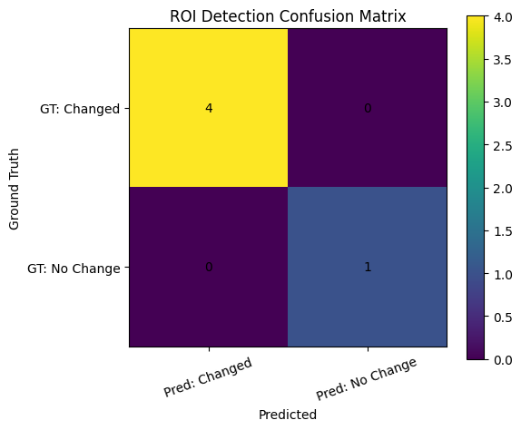

```python
# Purpose:
#   Visualize ROI-level confusion matrix using matplotlib.
# Inputs:
#   df_confusion
# Outputs:
#   displayed confusion matrix plot

import matplotlib.pyplot as plt
import numpy as np

cm = df_confusion.values

plt.figure(figsize=(6, 5))
plt.imshow(cm, interpolation="nearest")
plt.title("ROI Detection Confusion Matrix")
plt.colorbar()

tick_marks_x = np.arange(len(df_confusion.columns))
tick_marks_y = np.arange(len(df_confusion.index))

plt.xticks(tick_marks_x, df_confusion.columns, rotation=20)
plt.yticks(tick_marks_y, df_confusion.index)

for i in range(cm.shape[0]):
    for j in range(cm.shape[1]):
        plt.text(j, i, str(cm[i, j]), ha="center", va="center")

plt.xlabel("Predicted")
plt.ylabel("Ground Truth")
plt.tight_layout()
plt.show()
```

### STEP 85 — Visualize Drawing Checker Evaluation Metrics

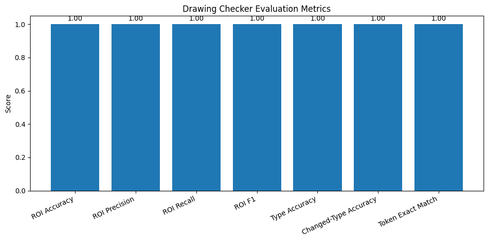

```python
# Purpose:
#   Visualize key evaluation metrics as a bar chart.
# Inputs:
#   roi_detection_metrics, classification_metrics, token_metrics
# Outputs:
#   displayed metrics bar chart

import matplotlib.pyplot as plt

metric_names = [
    "ROI Accuracy",
    "ROI Precision",
    "ROI Recall",
    "ROI F1",
    "Type Accuracy",
    "Changed-Type Accuracy",
    "Token Exact Match"
]

metric_values = [
    roi_detection_metrics.get("accuracy", 0.0),
    roi_detection_metrics.get("precision", 0.0),
    roi_detection_metrics.get("recall", 0.0),
    roi_detection_metrics.get("f1_score", 0.0),
    classification_metrics.get("overall_classification_accuracy", 0.0),
    classification_metrics.get("changed_only_classification_accuracy", 0.0),
    token_metrics.get("token_exact_match_accuracy", 0.0)
]

plt.figure(figsize=(10, 5))
bars = plt.bar(metric_names, metric_values)

plt.ylim(0, 1.05)
plt.title("Drawing Checker Evaluation Metrics")
plt.ylabel("Score")
plt.xticks(rotation=25, ha="right")

for bar, value in zip(bars, metric_values):
    plt.text(
        bar.get_x() + bar.get_width() / 2,
        value + 0.02,
        f"{value:.2f}",
        ha="center"
    )

plt.tight_layout()
plt.show()
```

### STEP 86 — Visualize ROI Detection Outcome Counts (TP/TN/FP/FN)

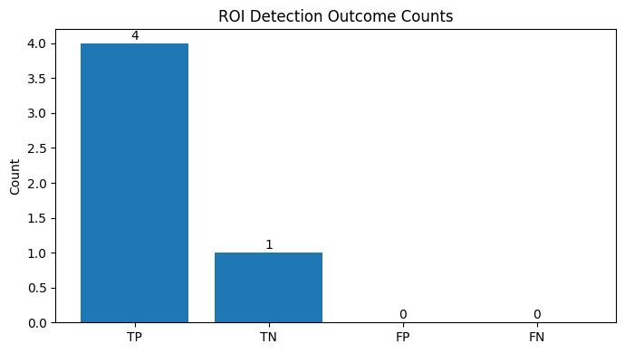

```python
# Purpose:
#   Show count of TP, TN, FP, FN outcomes.
# Inputs:
#   roi_detection_rows
# Outputs:
#   displayed outcome count chart

import matplotlib.pyplot as plt
from collections import Counter

outcome_counts = Counter([row["outcome"] for row in roi_detection_rows])

labels = ["TP", "TN", "FP", "FN"]
values = [outcome_counts.get(x, 0) for x in labels]

plt.figure(figsize=(7, 4))
bars = plt.bar(labels, values)

plt.title("ROI Detection Outcome Counts")
plt.ylabel("Count")

for bar, value in zip(bars, values):
    plt.text(
        bar.get_x() + bar.get_width() / 2,
        value + 0.05,
        str(value),
        ha="center"
    )

plt.tight_layout()
plt.show()
```

### STEP 87 — Save Evaluation Charts and Confusion Matrix Images

```python
# Purpose:
#   Save confusion matrix and metrics charts as PNG files.
# Inputs:
#   previously computed metrics and confusion matrix
# Outputs:
#   saved image files

import matplotlib.pyplot as plt
import numpy as np
from collections import Counter

# ---- Save confusion matrix ----
cm = df_confusion.values

plt.figure(figsize=(6, 5))
plt.imshow(cm, interpolation="nearest")
plt.title("ROI Detection Confusion Matrix")
plt.colorbar()

tick_marks_x = np.arange(len(df_confusion.columns))
tick_marks_y = np.arange(len(df_confusion.index))

plt.xticks(tick_marks_x, df_confusion.columns, rotation=20)
plt.yticks(tick_marks_y, df_confusion.index)

for i in range(cm.shape[0]):
    for j in range(cm.shape[1]):
        plt.text(j, i, str(cm[i, j]), ha="center", va="center")

plt.xlabel("Predicted")
plt.ylabel("Ground Truth")
plt.tight_layout()
plt.savefig("roi_confusion_matrix.png", dpi=200, bbox_inches="tight")
plt.close()

# ---- Save evaluation metrics chart ----
metric_names = [
    "ROI Accuracy",
    "ROI Precision",
    "ROI Recall",
    "ROI F1",
    "Type Accuracy",
    "Changed-Type Accuracy",
    "Token Exact Match"
]

metric_values = [
    roi_detection_metrics.get("accuracy", 0.0),
    roi_detection_metrics.get("precision", 0.0),
    roi_detection_metrics.get("recall", 0.0),
    roi_detection_metrics.get("f1_score", 0.0),
    classification_metrics.get("overall_classification_accuracy", 0.0),
    classification_metrics.get("changed_only_classification_accuracy", 0.0),
    token_metrics.get("token_exact_match_accuracy", 0.0)
]

plt.figure(figsize=(10, 5))
bars = plt.bar(metric_names, metric_values)
plt.ylim(0, 1.05)
plt.title("Drawing Checker Evaluation Metrics")
plt.ylabel("Score")
plt.xticks(rotation=25, ha="right")

for bar, value in zip(bars, metric_values):
    plt.text(
        bar.get_x() + bar.get_width() / 2,
        value + 0.02,
        f"{value:.2f}",
        ha="center"
    )

plt.tight_layout()
plt.savefig("drawing_checker_metrics.png", dpi=200, bbox_inches="tight")
plt.close()

# ---- Save outcome counts chart ----
outcome_counts = Counter([row["outcome"] for row in roi_detection_rows])
labels = ["TP", "TN", "FP", "FN"]
values = [outcome_counts.get(x, 0) for x in labels]

plt.figure(figsize=(7, 4))
bars = plt.bar(labels, values)
plt.title("ROI Detection Outcome Counts")
plt.ylabel("Count")

for bar, value in zip(bars, values):
    plt.text(
        bar.get_x() + bar.get_width() / 2,
        value + 0.05,
        str(value),
        ha="center"
    )

plt.tight_layout()
plt.savefig("roi_outcome_counts.png", dpi=200, bbox_inches="tight")
plt.close()

print("STEP 87 complete.")
print("Saved files:")
print("- roi_confusion_matrix.png")
print("- drawing_checker_metrics.png")
print("- roi_outcome_counts.png")
```

```
STEP 87 complete.
Saved files:
- roi_confusion_matrix.png
- drawing_checker_metrics.png
- roi_outcome_counts.png
```

## Key Findings

From the evaluation results, several observations can be made:

1. The system successfully detects most visual differences between drawing revisions using pixel-based ROI comparison.
2. OCR-based token extraction enables identification of engineering annotations such as labels and dimensions.
3. Label additions and removals are detected reliably when OCR text is stable.
4. Dimension modifications can be inferred by pairing removed and added numeric tokens within a tolerance range.
5. Some OCR noise can introduce false token candidates, requiring additional filtering.

These findings demonstrate that combining pixel comparison and token analysis can provide meaningful assistance during engineering drawing reviews.

## Insights

The experiment highlights several practical insights:

1. Pixel change detection alone is insufficient to understand engineering intent.
2. OCR-based token analysis improves interpretation of drawing differences.
3. Engineering token categories (labels, linear dimensions, angles) help organize detected changes.
4. Lightweight heuristics can significantly reduce OCR noise.
5. Confidence assessment is useful when OCR results are unstable.

These insights suggest that hybrid approaches combining visual detection and semantic token analysis are promising for automated drawing comparison.

## Limitations

The current prototype has several limitations:

1. OCR accuracy depends on drawing clarity and resolution.
2. Complex GD&T symbols are not fully interpreted.
3. The ROI template must be defined manually.
4. Small geometric changes inside views may not be fully detected.
5. The system has been evaluated on a limited drawing pair.

Future improvements can address these limitations.

## Future Work / Recommendations

Future Work

1. Several improvements can extend the system capabilities:
2. Automatic ROI detection using deep learning.
3. Improved OCR preprocessing for technical drawings.
4. Detection of GD&T and welding symbols.
5. Integration with CAD APIs for model-based comparison.
6. Deployment as a web-based engineering review tool.

## Conclusion

This project demonstrates a prototype system for automated engineering drawing comparison using computer vision and OCR techniques. By combining pixel-level change detection with engineering token analysis, the system can identify potential differences between drawing revisions and produce structured change summaries. Although the current prototype has limitations, the approach shows promise for assisting engineers in revision review workflows.

```python
!jupyter nbconvert --to html "/content/drive/MyDrive/Drawing_Checker/Drawing_Checker.ipynb"
```

```
[NbConvertApp] Converting notebook /content/drive/MyDrive/Drawing_Checker/Drawing_Checker.ipynb to html
[NbConvertApp] WARNING | Alternative text is missing on 12 image(s).
[NbConvertApp] Writing 1633706 bytes to /content/drive/MyDrive/Drawing_Checker/Drawing_Checker.html
```